# Exámen módulo IV_Año 2020

Yulia Frenkel

01 06 2020

# Ejercicio 1

#Considere la base de datos “ehd” incluída en la librería “psy”.

#Busque en la documentación la información asociada a cada una de las variables y realice un resumen sumario de la misma.

#Se considera evaluar la varianza común de los datos utilizando el método de máxima verosimilitud. Si los datos son adecuados, determine el número ideal de factores a obtener, realice el análisis e interprete los factores finalmente obtenidos.

```r
library(psy)
library(psych)
# Carga de datos
data ('ehd')
colnames(ehd) <-c("painfull sadness ", "hyperexpressiveness", "instability", "Observed monotony", "Lack expressivity", "Lack reactivity", "incontinence", "hyperesthesia", "observed explosive mood", "Worried gesture", "Observed anhedonia", "Felt sadness", "Situational anhedonia", "affective indifference", "Hypersensibility events", "Sensory anhedonia", "affective monotony", "hyperemotionalism", "irritability", "felt explosive mood")
str(ehd)
```

```
## 'data.frame':    269 obs. of  20 variables:
##  $ painfull sadness       : int  0 2 3 3 3 3 4 2 4 3 ...
##  $ hyperexpressiveness    : int  2 2 0 2 0 0 3 0 0 0 ...
##  $ instability            : int  0 2 3 2 0 0 0 0 0 0 ...
##  $ Observed monotony      : int  0 0 0 0 2 3 3 4 3 3 ...
##  $ Lack expressivity      : int  0 0 0 0 0 3 0 3 2 2 ...
##  $ Lack reactivity        : int  0 0 0 0 2 2 0 3 0 0 ...
##  $ incontinence           : int  0 3 0 2 2 0 2 0 2 0 ...
##  $ hyperesthesia          : int  2 0 0 0 2 0 0 0 0 0 ...
##  $ observed explosive mood: int  0 3 0 1 2 0 0 0 0 0 ...
##  $ Worried gesture        : int  2 0 1 2 2 0 0 0 2 2 ...
##  $ Observed anhedonia     : int  0 4 3 3 4 3 4 4 4 3 ...
##  $ Felt sadness           : int  2 0 3 2 2 3 4 2 4 3 ...
##  $ Situational anhedonia  : int  0 4 3 3 4 3 4 4 4 3 ...
##  $ affective indifference : int  0 4 0 0 0 0 3 3 0 0 ...
##  $ Hypersensibility events: int  0 0 3 3 4 3 0 0 2 2 ...
##  $ Sensory anhedonia      : int  0 0 0 0 0 0 3 4 0 3 ...
##  $ affective monotony     : int  0 0 0 2 0 0 3 4 4 3 ...
##  $ hyperemotionalism      : int  3 0 2 3 3 2 0 0 3 3 ...
##  $ irritability           : int  0 0 3 3 3 3 0 2 3 3 ...
##  $ felt explosive mood    : int  0 0 0 3 3 3 0 0 0 2 ...
```

```r
summary(ehd)
```

```
##  painfull sadness  hyperexpressiveness  instability     Observed monotony
##  Min.   :0.000     Min.   :0.000       Min.   :0.0000   Min.   :0.000
##  1st Qu.:1.000     1st Qu.:0.000       1st Qu.:0.0000   1st Qu.:0.000
##  Median :3.000     Median :1.000       Median :0.0000   Median :2.000
##  Mean   :2.242     Mean   :1.301       Mean   :0.5799   Mean   :1.561
##  3rd Qu.:3.000     3rd Qu.:3.000       3rd Qu.:0.0000   3rd Qu.:3.000
##  Max.   :4.000     Max.   :4.000       Max.   :4.0000   Max.   :4.000
##  Lack expressivity Lack reactivity   incontinence   hyperesthesia
##  Min.   :0.0000    Min.   :0.0000   Min.   :0.000   Min.   :0.0000
##  1st Qu.:0.0000    1st Qu.:0.0000   1st Qu.:0.000   1st Qu.:0.0000
##  Median :0.0000    Median :0.0000   Median :0.000   Median :0.0000
##  Mean   :0.9628    Mean   :0.5985   Mean   :1.089   Mean   :0.8773
##  3rd Qu.:2.0000    3rd Qu.:1.0000   3rd Qu.:2.000   3rd Qu.:2.0000
##  Max.   :4.0000    Max.   :4.0000   Max.   :4.000   Max.   :4.0000
##  observed explosive mood Worried gesture Observed anhedonia  Felt sadness
##  Min.   :0.0000          Min.   :0.000   Min.   :0.000      Min.   :0.000
##  1st Qu.:0.0000          1st Qu.:0.000   1st Qu.:1.000      1st Qu.:1.000
##  Median :0.0000          Median :2.000   Median :3.000      Median :2.000
##  Mean   :0.3346          Mean   :1.569   Mean   :2.253      Mean   :2.104
##  3rd Qu.:0.0000          3rd Qu.:2.000   3rd Qu.:3.000      3rd Qu.:3.000
##  Max.   :4.0000          Max.   :4.000   Max.   :4.000      Max.   :4.000
##  Situational anhedonia affective indifference Hypersensibility events
##  Min.   :0.000         Min.   :0.0000         Min.   :0.000
##  1st Qu.:1.000         1st Qu.:0.0000         1st Qu.:0.000
##  Median :2.000         Median :0.0000         Median :2.000
##  Mean   :2.138         Mean   :0.5056         Mean   :1.777
##  3rd Qu.:3.000         3rd Qu.:0.0000         3rd Qu.:3.000
##  Max.   :4.000         Max.   :4.0000         Max.   :4.000
##  Sensory anhedonia affective monotony hyperemotionalism  irritability
##  Min.   :0.0000    Min.   :0.000      Min.   :0.000     Min.   :0.000
##  1st Qu.:0.0000    1st Qu.:0.000      1st Qu.:0.000     1st Qu.:0.000
##  Median :0.0000    Median :0.000      Median :2.000     Median :2.000
##  Mean   :0.9108    Mean   :1.115      Mean   :1.703     Mean   :1.506
##  3rd Qu.:2.0000    3rd Qu.:2.000      3rd Qu.:3.000     3rd Qu.:3.000
##  Max.   :4.0000    Max.   :4.000      Max.   :4.000     Max.   :4.000
##  felt explosive mood
##  Min.   :0.0000
##  1st Qu.:0.0000
##  Median :0.0000
##  Mean   :0.8662
##  3rd Qu.:2.0000
##  Max.   :4.0000
```

```r
# help('ehd', package = 'psy')
# comprobamos si faltan valores
sapply(ehd, function(x) sum(is.na(x)))
```

```
##       painfull sadness      hyperexpressiveness             instability
##                       0                       0                       0
##       Observed monotony       Lack expressivity         Lack reactivity
##                       0                       0                       0
##            incontinence           hyperesthesia observed explosive mood
##                       0                       0                       0
##         Worried gesture      Observed anhedonia            Felt sadness
##                       0                       0                       0
##   Situational anhedonia  affective indifference Hypersensibility events
##                       0                       0                       0
##       Sensory anhedonia      affective monotony       hyperemotionalism
##                       0                       0                       0
##            irritability     felt explosive mood
##                       0                       0
```

#Tamaño muestral es bastante: La muestra no debe ser inferior a 50 observaciones. Lo aconsejable es que sea >= 100. Como regla general, deben tenerse por lo menos cinco veces más observaciones que variables, tomando como ratio óptimo un ratio de diez a uno.

```r
# Cálculo de la matriz de correlaciones
correl=cor(ehd,use="pairwise.complete.obs")
correl
```

```
##                         painfull sadness  hyperexpressiveness instability
## painfull sadness              1.000000000          0.22756329 -0.04363481
## hyperexpressiveness           0.227563287          1.00000000  0.50068645
## instability                  -0.043634815          0.50068645  1.00000000
## Observed monotony             0.341078547         -0.47697093 -0.55086080
## Lack expressivity             0.238665832         -0.46443370 -0.36390858
## Lack reactivity               0.186761888         -0.40834887 -0.29387286
## incontinence                  0.330442497          0.57258914  0.42411282
## hyperesthesia                 0.055212634          0.24706351  0.15705607
## observed explosive mood       0.004353406          0.30016978  0.44165590
## Worried gesture               0.415792528          0.34144148  0.02666560
## Observed anhedonia            0.644806931          0.06643552 -0.09219066
## Felt sadness                  0.672905191          0.33945694  0.07282816
## Situational anhedonia         0.590339159          0.06385457 -0.05178785
## affective indifference        0.142841053         -0.17969598 -0.13888690
## Hypersensibility events       0.257538194          0.28784879  0.21393291
## Sensory anhedonia             0.321446097         -0.01798515 -0.14188544
## affective monotony            0.305722159         -0.20701445 -0.21845227
## hyperemotionalism             0.291550662          0.39954403  0.21930225
## irritability                  0.206747254          0.25114643  0.22001714
## felt explosive mood           0.083214787          0.27586085  0.23171819
##                         Observed monotony Lack expressivity Lack reactivity
## painfull sadness             0.3410785473        0.23866583     0.186761888
## hyperexpressiveness         -0.4769709332       -0.46443370    -0.408348865
## instability                 -0.5508608034       -0.36390858    -0.293872859
## Observed monotony            1.0000000000        0.70161584     0.576946120
## Lack expressivity            0.7016158409        1.00000000     0.740826555
## Lack reactivity              0.5769461198        0.74082655     1.000000000
## incontinence                -0.2681628857       -0.20859325    -0.256478349
## hyperesthesia               -0.2581711489       -0.23065222    -0.214615119
## observed explosive mood     -0.2247651807       -0.12649573    -0.080678576
## Worried gesture              0.0002450484       -0.06555873    -0.007651557
## Observed anhedonia           0.3492684288        0.34843079     0.255449110
## Felt sadness                 0.0585620384       -0.02949866    -0.009841624
## Situational anhedonia        0.2645006060        0.20822695     0.169365394
## affective indifference       0.3171100462        0.30337671     0.289963893
## Hypersensibility events     -0.1607920904       -0.17160910    -0.142414151
## Sensory anhedonia            0.3093192264        0.20167353     0.193622932
## affective monotony           0.4786019230        0.43516297     0.358687559
## hyperemotionalism           -0.2440654323       -0.33150808    -0.242951693
```

[output cut: 113 more lines]

```
## Lack reactivity                 -0.16590068
## incontinence                     0.17195072
## hyperesthesia                    0.19997615
## observed explosive mood          0.31227178
## Worried gesture                  0.12844459
## Observed anhedonia               0.13054459
## Felt sadness                     0.12466049
## Situational anhedonia            0.15694245
## affective indifference          -0.25953298
## Hypersensibility events          0.50946057
## Sensory anhedonia               -0.05510879
## affective monotony              -0.23092327
## hyperemotionalism                0.42789854
## irritability                     0.69932916
## felt explosive mood              1.00000000
```

#Validez del modelo: Test de Esferidad de Barlett e Indice KMO de Kaiser-Meyer-Olkin.

```r
cortest.bartlett(ehd) #La prueba de esfericidad de Bartlett, contrasta la hipótesis nula de que la matriz de correlaciones es una matriz identidad, en cuyo caso no existirían correlaciones significativas entre las variables y el modelo factorial no sería pertinente.
```

```
## R was not square, finding R from data
```

```
## $chisq
## [1] 2788.754
##
## $p.value
## [1] 0
##
## $df
## [1] 190
```

```r
library(rela)
# Calcula automáticamente KMO con MSA, determina el número de factores.
# calcula chi-cuadrado de la prueba de esfericidad de Bartlett, comunalidades y
# cargas factoriales.
res <- paf(as.matrix(ehd))
summary(res)
```

```
## $KMO
## [1] 0.82688
##
## $MSA
##                             MSA
## painfull sadness        0.84371
## hyperexpressiveness     0.84954
## instability             0.84190
## Observed monotony       0.85569
## Lack expressivity       0.79680
## Lack reactivity         0.82816
## incontinence            0.81917
## hyperesthesia           0.81495
## observed explosive mood 0.74358
## Worried gesture         0.75684
## Observed anhedonia      0.79446
## Felt sadness            0.85288
## Situational anhedonia   0.75839
## affective indifference  0.82939
## Hypersensibility events 0.82469
## Sensory anhedonia       0.86716
## affective monotony      0.93932
## hyperemotionalism       0.89275
## irritability            0.80505
## felt explosive mood     0.81110
##
## $Bartlett
## [1] 2788.8
##
## $Communalities
##                         Initial Communalities Final Extraction
## painfull sadness                      0.69862          0.80695
## hyperexpressiveness                   0.59877          0.64679
## instability                           0.48086          0.53199
## Observed monotony                     0.68113          0.70894
## Lack expressivity                     0.71453          0.87151
## Lack reactivity                       0.58405          0.58962
## incontinence                          0.51269          0.56966
## hyperesthesia                         0.24269          0.15909
## observed explosive mood               0.38984          0.52556
```

[output cut: 22 more lines]

```
## observed explosive mood -0.395362 -0.094646  0.0540468 -0.5523372  0.228672
## Worried gesture         -0.270406 -0.338698 -0.0091772  0.3350675  0.127894
## Observed anhedonia       0.113818 -0.845268  0.0620757 -0.1463586 -0.144102
## Felt sadness            -0.241238 -0.641711  0.1770550  0.3139819  0.036984
## Situational anhedonia    0.071056 -0.810163  0.1134581 -0.1885049 -0.307153
## affective indifference   0.526053 -0.237394  0.3731760 -0.2574462 -0.159379
## Hypersensibility events -0.595644 -0.360345 -0.4254791  0.0093352 -0.023154
## Sensory anhedonia        0.250949 -0.412737  0.1100833 -0.0580645 -0.193150
## affective monotony       0.504409 -0.393434  0.1784117 -0.0916769 -0.025514
## hyperemotionalism       -0.609805 -0.296638 -0.1518387  0.2050737 -0.020919
## irritability            -0.585100 -0.323373 -0.4737507 -0.1828338 -0.113359
## felt explosive mood     -0.543171 -0.215493 -0.3845639 -0.2407124 -0.132769
##
## $RMS
## [1] 0.028692
```

#Indice KMO de Kaiser-Meyer-Olkin =0,82 que es “meritorio” para hacer analises factoral y Medida de Adecuación de la Muestra (MSA, mesure of sampling adequacy) es bueno tambien.

#Criterio del gráfico de sedimientación o del contraste de caída.

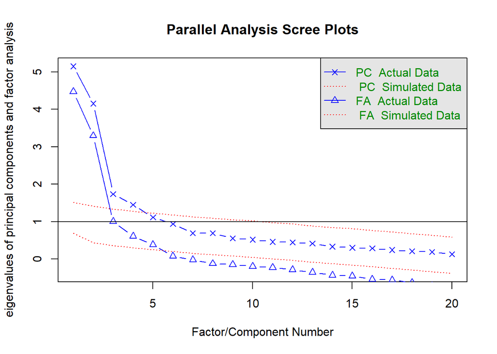

```
## Parallel analysis suggests that the number of factors =  5  and the number of components =  4
```

```r
fa.parallel(correl, n.obs = 269,  fm = "ml")
```

```r
# Como método de extracción utilizamos la  Máxima Verosimilitud ("ml")
# Representando el gráfico de sedimientación decidimos extrar 5 factores.
ehd.ps <- fa(correl, n.obs = 269, fm = "ml", nfactors = 5, rotate ="varimax")
print(ehd.ps) # Cargas factoriales en $loadings
```

```
## Factor Analysis using method =  ml
## Call: fa(r = correl, nfactors = 5, n.obs = 269, rotate = "varimax",
##     fm = "ml")
## Standardized loadings (pattern matrix) based upon correlation matrix
##                           ML1   ML3   ML2   ML4   ML5   h2   u2 com
## painfull sadness         0.47  0.10  0.22  0.72  0.03 0.80 0.20 2.0
## hyperexpressiveness     -0.03  0.12 -0.40  0.43  0.53 0.64 0.36 3.0
## instability             -0.10  0.12 -0.27  0.03  0.69 0.57 0.43 1.4
## Observed monotony        0.29 -0.14  0.65  0.09 -0.41 0.70 0.30 2.3
## Lack expressivity        0.21 -0.14  0.89 -0.05 -0.12 0.87 0.13 1.2
## Lack reactivity          0.17 -0.09  0.75 -0.06 -0.13 0.61 0.39 1.2
## incontinence             0.03  0.08 -0.13  0.45  0.58 0.57 0.43 2.1
## hyperesthesia           -0.07  0.23 -0.18  0.12  0.19 0.14 0.86 3.7
## observed explosive mood  0.04  0.26 -0.01 -0.10  0.60 0.44 0.56 1.4
## Worried gesture          0.03  0.17 -0.03  0.52  0.00 0.30 0.70 1.2
## Observed anhedonia       0.80  0.18  0.24  0.28  0.06 0.82 0.18 1.6
## Felt sadness             0.31  0.12 -0.04  0.71  0.06 0.62 0.38 1.5
## Situational anhedonia    0.90  0.20  0.06  0.18  0.04 0.88 0.12 1.2
## affective indifference   0.53 -0.43  0.15 -0.16  0.00 0.52 0.48 2.3
## Hypersensibility events  0.02  0.76 -0.06  0.27  0.12 0.67 0.33 1.3
## Sensory anhedonia        0.47 -0.07  0.11  0.10 -0.11 0.26 0.74 1.4
## affective monotony       0.47 -0.29  0.33  0.05 -0.10 0.42 0.58 2.7
## hyperemotionalism       -0.04  0.51 -0.24  0.45  0.11 0.54 0.46 2.5
## irritability             0.03  0.80 -0.06  0.13  0.16 0.69 0.31 1.1
## felt explosive mood      0.02  0.71 -0.10  0.02  0.19 0.56 0.44 1.2
##
##                        ML1  ML3  ML2  ML4  ML5
## SS loadings           2.68 2.60 2.39 2.16 1.80
## Proportion Var        0.13 0.13 0.12 0.11 0.09
## Cumulative Var        0.13 0.26 0.38 0.49 0.58
## Proportion Explained  0.23 0.22 0.21 0.19 0.15
## Cumulative Proportion 0.23 0.45 0.66 0.85 1.00
##
## Mean item complexity =  1.8
## Test of the hypothesis that 5 factors are sufficient.
##
## The degrees of freedom for the null model are  190  and the objective function was  10.71 with Chi Square of  2788.8
## The degrees of freedom for the model are 100  and the objective function was  0.81
##
## The root mean square of the residuals (RMSR) is  0.03
## The df corrected root mean square of the residuals is  0.04
##
## The harmonic number of observations is  269 with the empirical chi square  97  with prob <  0.57
## The total number of observations was  269  with Likelihood Chi Square =  209.46  with prob <  9.6e-10
##
## Tucker Lewis Index of factoring reliability =  0.919
## RMSEA index =  0.064  and the 90 % confidence intervals are  0.052 0.076
## BIC =  -350.02
## Fit based upon off diagonal values = 0.99
## Measures of factor score adequacy
##                                                    ML1  ML3  ML2  ML4  ML5
## Correlation of (regression) scores with factors   0.95 0.92 0.93 0.90 0.86
## Multiple R square of scores with factors          0.90 0.84 0.87 0.81 0.74
## Minimum correlation of possible factor scores     0.79 0.68 0.74 0.61 0.48
```

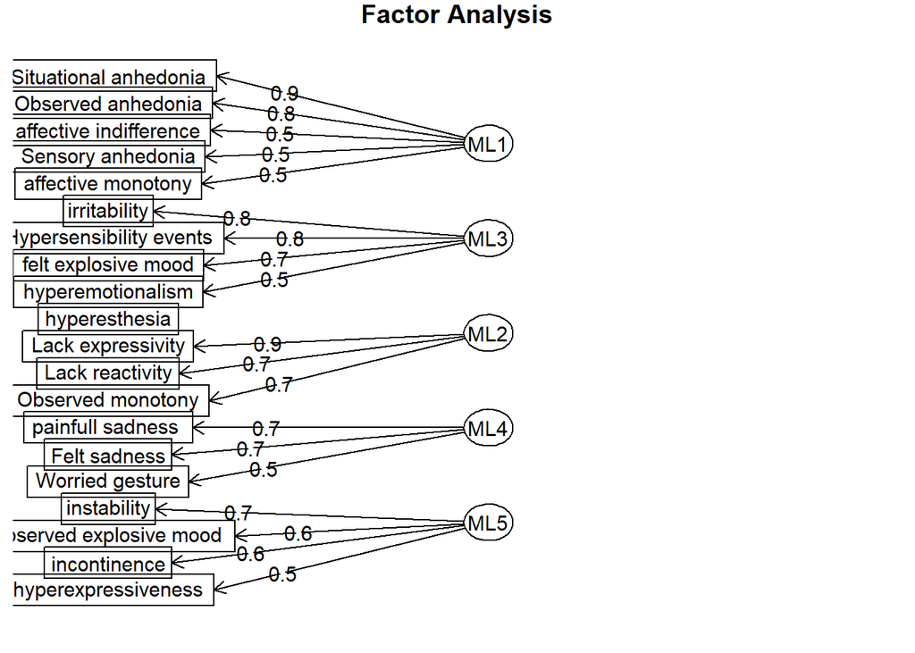

```r
fa.diagram(ehd.ps)
```

```r
# La función factanal realiza el Analsis Factorial de Máxima Verosimilitud.
library(psych)
ehd.fa <- factanal(ehd, factors=5, rotation="varimax", scores = "Bartlett")
ehd.fa
```

```
##
## Call:
## factanal(x = ehd, factors = 5, scores = "Bartlett", rotation = "varimax")
##
## Uniquenesses:
##       painfull sadness      hyperexpressiveness             instability
##                   0.205                   0.356                   0.430
##       Observed monotony       Lack expressivity         Lack reactivity
##                   0.295                   0.126                   0.386
##            incontinence           hyperesthesia observed explosive mood
##                   0.435                   0.858                   0.562
##         Worried gesture      Observed anhedonia            Felt sadness
##                   0.698                   0.182                   0.379
##   Situational anhedonia  affective indifference Hypersensibility events
##                   0.115                   0.476                   0.333
##       Sensory anhedonia      affective monotony       hyperemotionalism
##                   0.740                   0.577                   0.463
##            irritability     felt explosive mood
##                   0.311                   0.441
##
## Loadings:
##                         Factor1 Factor2 Factor3 Factor4 Factor5
## painfull sadness         0.474   0.102   0.218   0.715
## hyperexpressiveness              0.121  -0.402   0.428   0.533
## instability             -0.103   0.120  -0.273           0.685
## Observed monotony        0.289  -0.141   0.652          -0.411
## Lack expressivity        0.213  -0.138   0.890          -0.123
## Lack reactivity          0.169           0.747          -0.128
## incontinence                            -0.135   0.454   0.577
## hyperesthesia                    0.228  -0.180   0.123   0.192
## observed explosive mood          0.261                   0.599
## Worried gesture                  0.170           0.520
## Observed anhedonia       0.804   0.182   0.238   0.279
## Felt sadness             0.310   0.118           0.710
## Situational anhedonia    0.898   0.199           0.184
## affective indifference   0.534  -0.435   0.154  -0.162
## Hypersensibility events          0.758           0.273   0.115
## Sensory anhedonia        0.470           0.110   0.102  -0.109
## affective monotony       0.468  -0.288   0.331
## hyperemotionalism                0.514  -0.239   0.450   0.105
## irritability                     0.802           0.130   0.155
## felt explosive mood              0.715                   0.194
##
##                Factor1 Factor2 Factor3 Factor4 Factor5
## SS loadings      2.679   2.599   2.392   2.161   1.801
## Proportion Var   0.134   0.130   0.120   0.108   0.090
## Cumulative Var   0.134   0.264   0.383   0.492   0.582
##
## Test of the hypothesis that 5 factors are sufficient.
## The chi square statistic is 209.46 on 100 degrees of freedom.
## The p-value is 9.64e-10
```

```r
# Puntuaciones
ehd.fa.puntuaciones <- ehd.fa$scores
head(ehd.fa.puntuaciones)
```

```
##        Factor1  Factor2   Factor3   Factor4   Factor5
## [1,] -1.496370 -0.91815 -0.965435 -0.076037 -0.539888
## [2,]  2.374700 -1.61279 -1.003108 -2.235970  3.393321
## [3,]  0.618349  0.73017 -0.872932 -0.164115 -0.039403
## [4,]  0.506737  1.14262 -0.534211 -0.096431  1.059317
## [5,]  1.082587  2.18750 -0.074028 -0.529827 -0.086346
## [6,]  0.087485  1.82552  1.758607 -0.278011 -0.669600
```

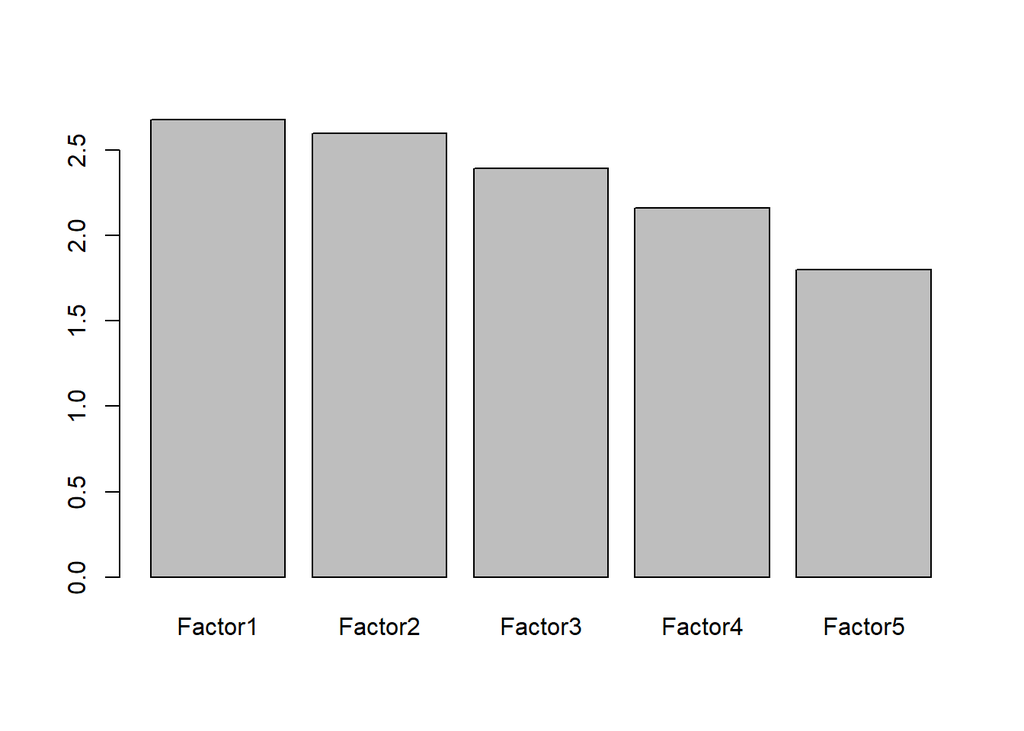

```r
barplot(sort(colSums(loadings(ehd.fa)^2),decreasing=TRUE))
```

# Ejercicio 2

#El fichero “socioecconomica.xlsx” contiene información sobre la evolución del paro en la provincia de Cantabria desde el año 2005 hasta el primer trimestre de 2020.

#Seleccione las tasas de paro y evalúe la similitud en la evolución de las series a través de un escalamiento multidimensional no métrico.

#Una vez reducida la dimensionalidad, realice un cluster agrupando las series que presenten comportamientos similares y establezca las conclusiones oportunas.

```r
library(dplyr)
library(tidyr)
paro <- read.csv2("socioeconomica.csv")
paro<-paro %>% unite("time", Ano, Trimestre)
row.names(paro)<-paro$time
str (paro)
```

```
## 'data.frame':    61 obs. of  17 variables:
##  $ time                          : chr  "2005_1" "2005_2" "2005_3" "2005_4" ...
##  $ Hombres.16.24                 : num  16.1 13.3 12.9 15.4 13.6 ...
##  $ Hombres.25.54                 : num  6.09 5.55 5.19 4.91 3.97 ...
##  $ Hombres.55.64                 : num  4.31 4.71 4.94 6.48 4.53 ...
##  $ Hombres.Total                 : num  6.92 6.15 5.99 6.08 4.91 ...
##  $ Mujeres.16.24                 : num  26.1 24.9 16.3 23.4 22.7 ...
##  $ Mujeres.25.54                 : num  13.75 12.85 8.23 9.91 9.16 ...
##  $ Mujeres.55.64                 : num  5.82 4.19 3.36 2.13 3.36 ...
##  $ Mujeres.Total                 : num  14.28 13.4 8.69 10.73 10.1 ...
##  $ Total.16.24                   : num  19.9 18.8 14.3 19 17.7 ...
##  $ Total.25.54                   : num  9.28 8.54 6.45 7.03 6.2 ...
##  $ Total.55.64                   : num  4.8 4.51 4.36 4.91 4.13 ...
##  $ Total.Total                   : num  9.89 9.15 7.1 8.04 7.11 ...
##  $ Total.Jovenes                 : num  17.1 15.3 10.9 14.7 11.9 ...
##  $ Total.No.cualificadas         : num  9.51 6.76 6.77 8.25 9.3 ...
##  $ Parados.Larga.Duracion.16.67  : num  9085 7245 6191 6080 4836 ...
##  $ Parados.Larga.Duracion.Jovenes: num  2968 2912 1373 1953 1468 ...
```

```r
summary(paro)
```

```
##      time           Hombres.16.24   Hombres.25.54   Hombres.55.64
##  Length:61          Min.   : 5.08   Min.   : 2.87   Min.   : 0.413
##  Class :character   1st Qu.:18.52   1st Qu.: 7.84   1st Qu.: 4.936
##  Mode  :character   Median :33.69   Median :11.69   Median : 8.686
##                     Mean   :32.11   Mean   :11.44   Mean   : 9.069
##                     3rd Qu.:41.68   3rd Qu.:15.60   3rd Qu.:12.907
##                     Max.   :65.31   Max.   :20.87   Max.   :19.844
##  Hombres.Total   Mujeres.16.24  Mujeres.25.54   Mujeres.55.64   Mujeres.Total
##  Min.   : 3.33   Min.   :16.3   Min.   : 5.39   Min.   : 0.00   Min.   : 6.62
##  1st Qu.: 7.93   1st Qu.:24.7   1st Qu.: 9.41   1st Qu.: 5.46   1st Qu.:10.35
##  Median :12.67   Median :33.5   Median :12.87   Median : 8.51   Median :13.40
##  Mean   :12.21   Mean   :33.5   Mean   :13.40   Mean   : 7.95   Mean   :13.95
##  3rd Qu.:16.50   3rd Qu.:41.7   3rd Qu.:16.83   3rd Qu.:10.41   3rd Qu.:16.72
##  Max.   :21.79   Max.   :52.3   Max.   :22.78   Max.   :13.91   Max.   :23.14
##   Total.16.24    Total.25.54     Total.55.64     Total.Total    Total.Jovenes
##  Min.   :10.8   Min.   : 4.67   Min.   : 1.19   Min.   : 4.76   Min.   : 6.08
##  1st Qu.:22.6   1st Qu.: 8.41   1st Qu.: 4.91   1st Qu.: 9.04   1st Qu.:16.37
##  Median :34.3   Median :12.01   Median : 9.24   Median :12.72   Median :24.45
##  Mean   :32.8   Mean   :12.32   Mean   : 8.59   Mean   :12.97   Mean   :23.93
##  3rd Qu.:41.8   3rd Qu.:16.17   3rd Qu.:11.34   3rd Qu.:16.36   3rd Qu.:30.12
##  Max.   :56.2   Max.   :21.55   Max.   :16.71   Max.   :22.41   Max.   :40.87
##  Total.No.cualificadas Parados.Larga.Duracion.16.67
##  Min.   : 5.20         Min.   : 2653
##  1st Qu.: 8.99         1st Qu.: 7245
##  Median :13.03         Median :16177
##  Mean   :12.66         Mean   :16566
##  3rd Qu.:15.59         3rd Qu.:24226
##  Max.   :22.89         Max.   :34547
##  Parados.Larga.Duracion.Jovenes
##  Min.   : 114
##  1st Qu.:1543
##  Median :3663
##  Mean   :3385
##  3rd Qu.:5056
##  Max.   :7755
```

```r
paro <-t(paro [,-c(1,16,17)])
```

# NMDS de Kruskal

```r
library(MASS)
library(vegan)
d <- vegdist(paro, method = "gower")
# NMDS de Kruskal
nmds <- isoMDS(d)  # k=2
```

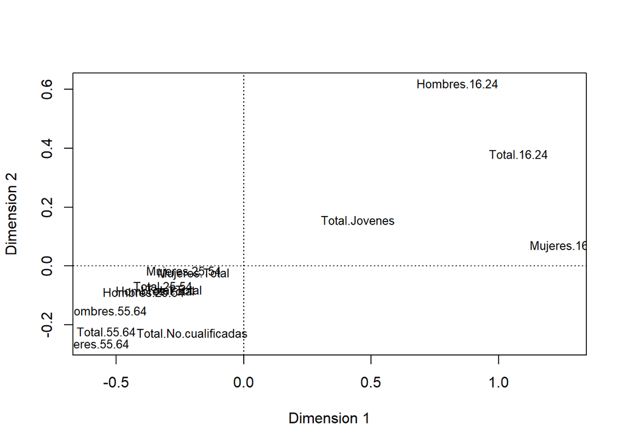

```r
plot(nmds$points, type = "n", xlab = "Dimensión 1", ylab = "Dimensión 2")
text(nmds$points, labels = rownames(nmds$points), cex = 0.8)
abline(h = 0, lty = 3)
abline(v = 0, lty = 3)
```

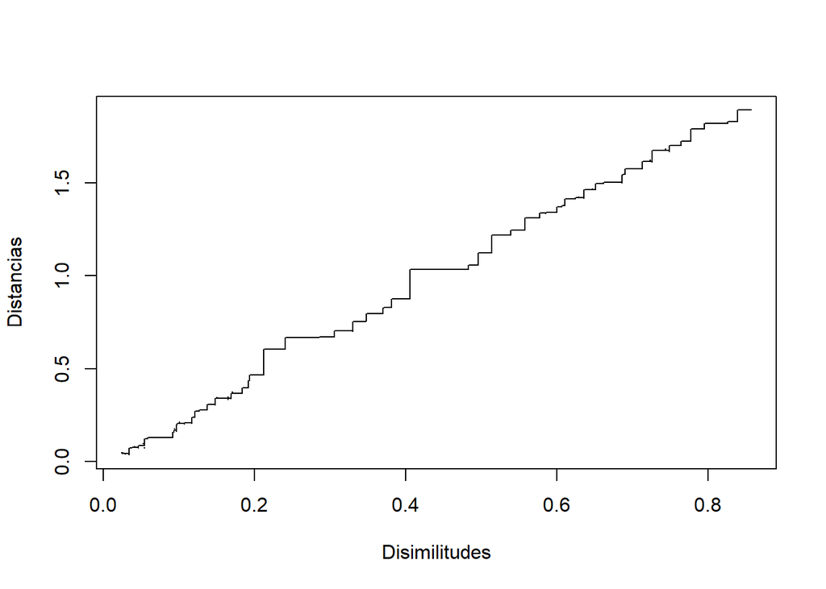

```r
# Diagrama de Shepard
nmds_sh <- Shepard(d, nmds$points)
plot(nmds_sh, pch=".", xlab="Disimilitudes", ylab="Distancias")
lines(nmds_sh$x, nmds_sh$yf, type="S")
```

# SMACOF

```r
library(smacof)
library(vegan)
d <- vegdist(paro, method = "gower")
nmds.smacof = mds(d, type = "ordinal")  # k=2
nmds.smacof
```

```
##
## Call:
## mds(delta = d, type = "ordinal")
##
## Model: Symmetric SMACOF
## Number of objects: 14
## Stress-1 value: 0.005
## Number of iterations: 20
```

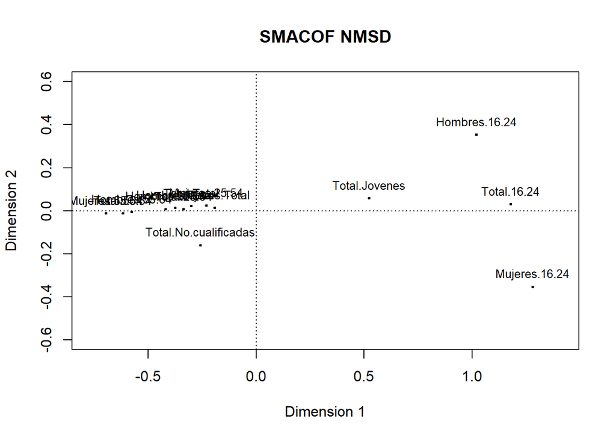

```r
# Gráficos
plot(nmds.smacof, main = "SMACOF NMSD", xlab = "Dimensión 1", ylab = "Dimensión 2", label.conf = list(cex = 0.8))
abline(h = 0, lty = 3)
abline(v = 0, lty = 3)
```

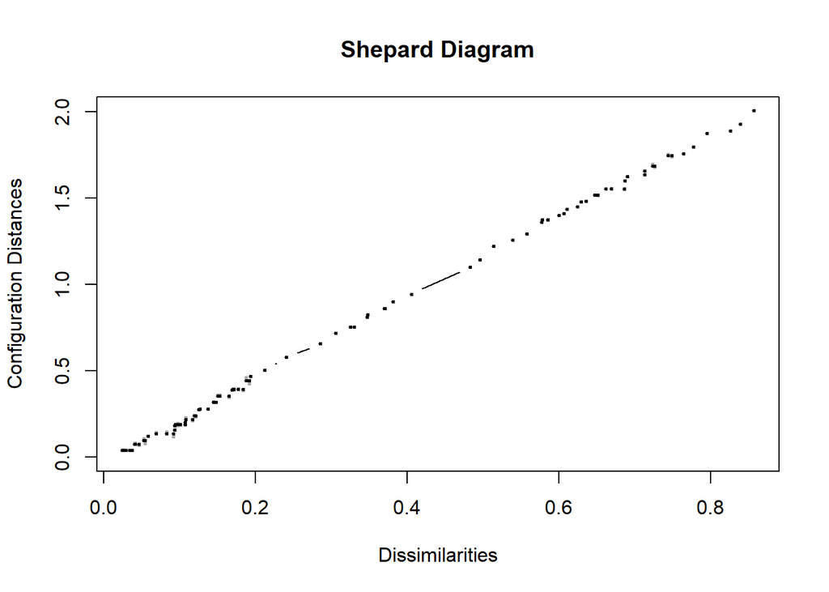

```r
plot(nmds.smacof, plot.type = "Shepard")
```

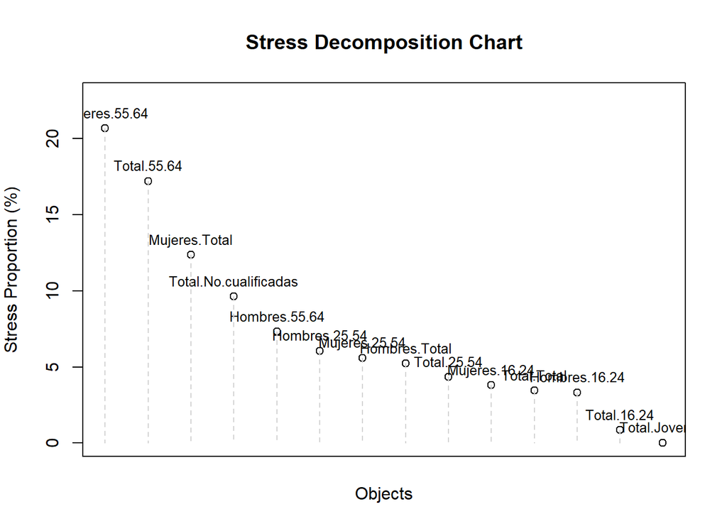

```r
plot(nmds.smacof, plot.type = "stressplot")
```

# VEGAN

```r
library(vegan)
nmds <- metaMDS(paro, distance = "euclidean")  # k=2
```

```
## Square root transformation
## Wisconsin double standardization
## *** Solution reached
```

```r
nmds
```

```
##
## Call:
## metaMDS(comm = paro, distance = "euclidean")
##
## global Multidimensional Scaling using monoMDS
##
## Data:     wisconsin(sqrt(paro))
## Distance: euclidean
##
## Dimensions: 2
## Stress:     0.091575
## Stress type 1, weak ties
## Two convergent solutions found after 20 tries
## Scaling: centring, PC rotation
## Species: expanded scores based on 'wisconsin(sqrt(paro))'
```

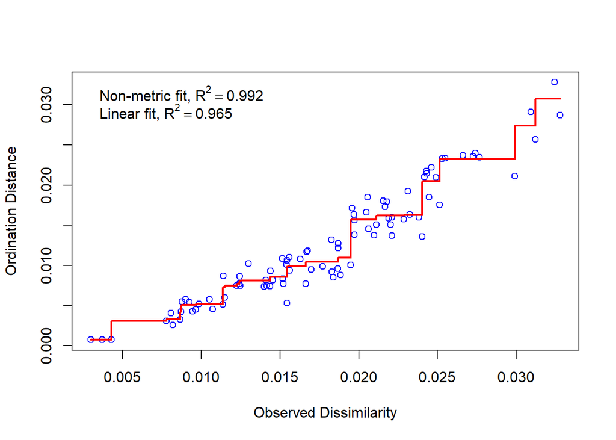

```r
stressplot(nmds)  # Diagrama de Shepard
```

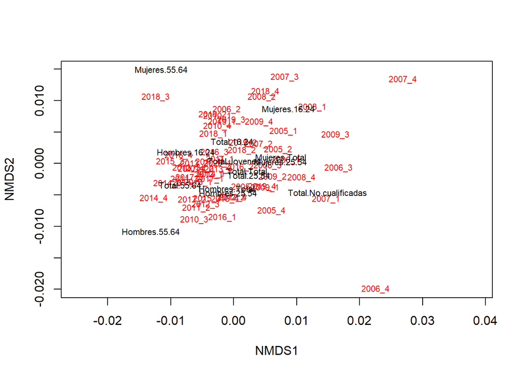

```r
ordiplot(nmds, type="n")
orditorp(nmds, display="species", col="red", air=0.01)  # variables
orditorp(nmds, display="sites", air=0.01)  # objetos
```

```r
library(smacof)
library(vegan)

d <- vegdist(paro, method = "gower")
nmds = mds(d, type = "ordinal")  # k=2
```

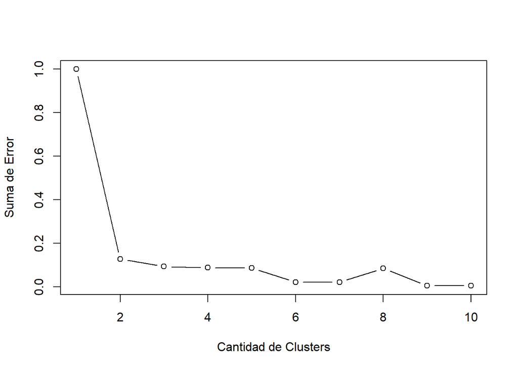

```r
K_Max <- 10
Errores <- NULL
set.seed(12345)

for (i in 1:K_Max){
    Errores[i] <- sum(kmeans(d, centers=i)$withinss)
    if (i == 1){
        Errores_max <- Errores[i]
    }
    Errores[i] <- Errores[i] / Errores_max
}
#Errores
#diff(Errores)

# Gráfico del vector "Errores"
plot(1:K_Max, Errores, type="b", xlab="Cantidad de Clusters", ylab="Suma de Error")
```

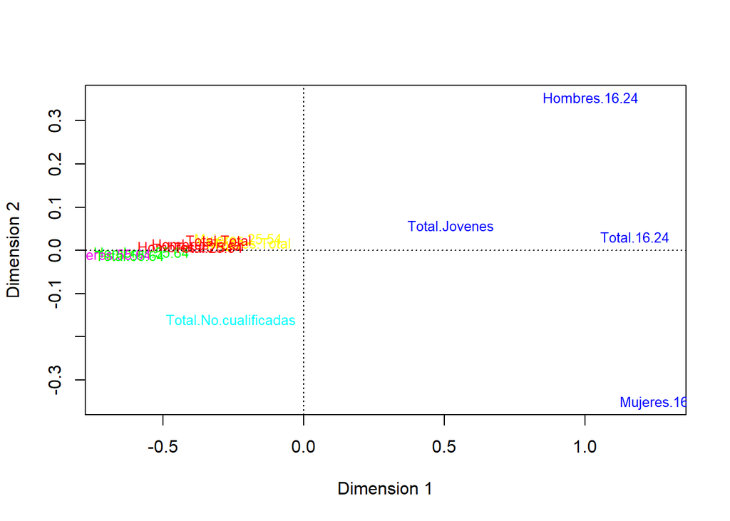

```r
# Creamos 6 grupos, mediante la función "k-means"
clust <- kmeans(nmds$conf, 6)$cluster
palette(rainbow(6))
plot(nmds$conf, type = "n", xlab = "Dimensión 1", ylab = "Dimensión 2")
text(nmds$conf, labels = rownames(nmds$conf), cex = 0.8, col = clust)
abline(h = 0, lty = 3)
abline(v = 0, lty = 3)
```

```r
library(dendextend)
cj=hclust(d, method = "complete")
cj
```

```
##
## Call:
## hclust(d = d, method = "complete")
##
## Cluster method   : complete
## Distance         : gower
## Number of objects: 14
```

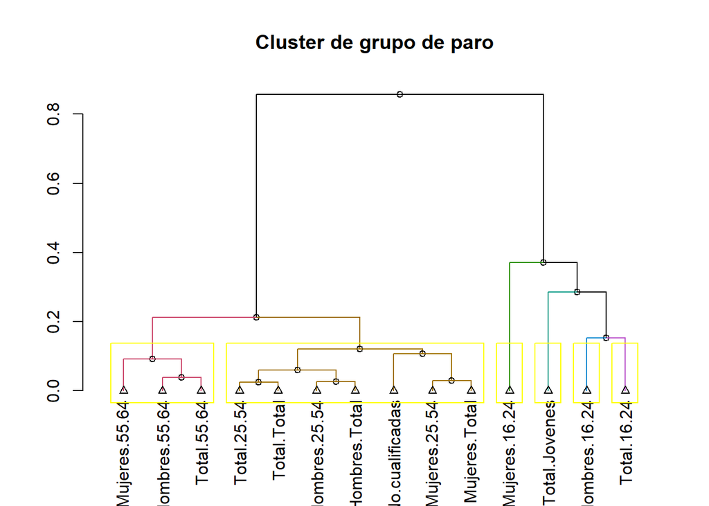

```r
dend <- color_branches(cj, k=6)
plot(dend, main = "Cluster de grupo de paro", horiz =  FALSE, nodePar = list(cex = .8))
rect.hclust(cj ,6)
```

#Del análisis se deduce que el grupo de desempleados de 16 a 24 años está muy alejado de los demás y requiere una consideración por separado. La diferencia entre los otros dos grupos no es tan significativa, aunque se destaca un grupo de personas de 55-64.

## Ejercicio 3

#El archivo “coffe.sav” contiene datos relativos a las imágen percibida de seis marcas de café helado. Para cada uno de los 23 atributos de imagen de café helado, los encuestados seleccionaron todas las marcas que quedaban descritas por el atributo. Las seis marcas se denotan AA, BB, CC, DD, EE y FF para mantener la confidencialidad.

#Analice la percepción asociada a las diferentes marcas.

```r
library('foreign')
library('reshape')
```

```r
library("gplots")
coffee<- read.spss('coffee.sav')
coffee<-as.data.frame(coffee)
str(coffee)
```

```
## 'data.frame':    138 obs. of  3 variables:
##  $ imagen: Factor w/ 23 levels "engorda","hombres",..: 1 2 3 4 5 6 7 8 9 10 ...
##  $ marca : Factor w/ 6 levels "AA","BB","CC",..: 1 1 1 1 1 1 1 1 1 1 ...
##  $ frec  : num  82 96 72 101 66 6 47 1 16 60 ...
```

```r
summary(coffee)
```

```
##             imagen    marca        frec
##  engorda       :  6   AA:23   Min.   :  0.0
##  hombres       :  6   BB:23   1st Qu.:  9.0
##  SudAustraliano:  6   CC:23   Median : 22.0
##  tradicional   :  6   DD:23   Mean   : 33.8
##  superior      :  6   EE:23   3rd Qu.: 47.8
##  sano          :  6   FF:23   Max.   :144.0
##  (Other)       :102
```

```r
head(coffee)
```

```
##           imagen marca frec
## 1        engorda    AA   82
## 2        hombres    AA   96
## 3 SudAustraliano    AA   72
## 4    tradicional    AA  101
## 5       superior    AA   66
## 6           sano    AA    6
```

```r
w <- reshape(coffee,
  timevar = "marca",
  idvar = "imagen",
   direction = "wide")
rownames(w)<-w$imagen
```

#En primer lugar, realizaremos una análisis exploratorio de los datos mediante una visualización de la tabla de contingencia.

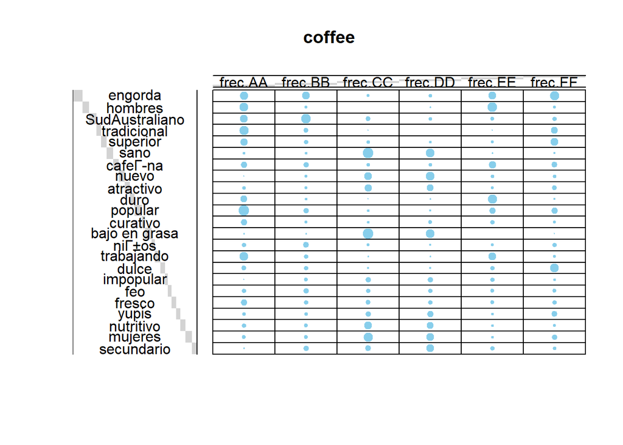

```r
library("gplots")
# 1. Convierto los datos a formato tabla
dt <- as.table(as.matrix(w [,-1]))
# 2. Gráfico de Contingencia
balloonplot(t(dt), main ="coffee", xlab ="", ylab="",
            label = FALSE, show.margins = FALSE)
```

```r
library("FactoMineR")
library("factoextra")
```

```r
res.ca <- CA(w[,-1], graph = FALSE)
print(res.ca)
```

```
## **Results of the Correspondence Analysis (CA)**
## The row variable has  23  categories; the column variable has 6 categories
## The chi square of independence between the two variables is equal to 3747 (p-value =  0 ).
## *The results are available in the following objects:
##
##    name              description
## 1  "$eig"            "eigenvalues"
## 2  "$col"            "results for the columns"
## 3  "$col$coord"      "coord. for the columns"
## 4  "$col$cos2"       "cos2 for the columns"
## 5  "$col$contrib"    "contributions of the columns"
## 6  "$row"            "results for the rows"
## 7  "$row$coord"      "coord. for the rows"
## 8  "$row$cos2"       "cos2 for the rows"
## 9  "$row$contrib"    "contributions of the rows"
## 10 "$call"           "summary called parameters"
## 11 "$call$marge.col" "weights of the columns"
## 12 "$call$marge.row" "weights of the rows"
```

# Valores propios

```r
library("factoextra")
eig.val <- get_eigenvalue(res.ca)
eig.val
```

```
##       eigenvalue variance.percent cumulative.variance.percent
## Dim.1   0.505807          62.9328                      62.933
## Dim.2   0.158998          19.7827                      82.715
## Dim.3   0.069361           8.6299                      91.345
## Dim.4   0.054910           6.8320                      98.177
## Dim.5   0.014649           1.8227                     100.000
```

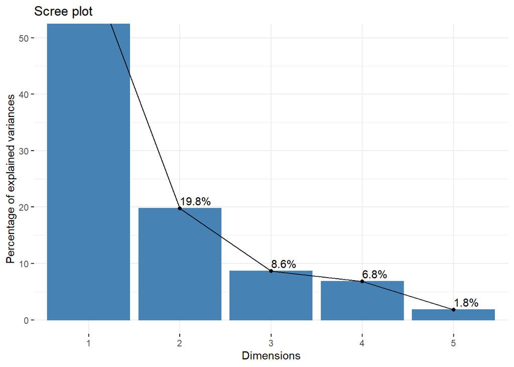

```r
fviz_screeplot(res.ca, addlabels = TRUE, ylim = c(0, 50))
```

#Como vemos en los resultados, alrededor del 82.7% de la variación se explica por las dos primeras dimensiones.

# Biplot simétrico

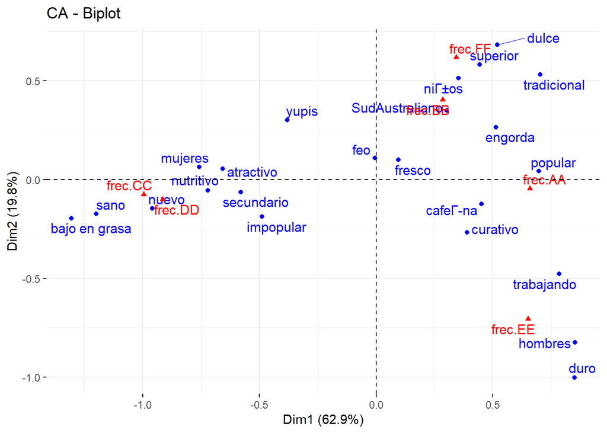

```r
# para dibujar el biplot de variables de filas y columnas (método de normailiación Principal).
fviz_ca_biplot(res.ca, repel = TRUE)
```

# Análisis de perfiles fila

```r
row <- get_ca_row(res.ca)
row
```

```
## Correspondence Analysis - Results for rows
##  ===================================================
##   Name       Description
## 1 "$coord"   "Coordinates for the rows"
## 2 "$cos2"    "Cos2 for the rows"
## 3 "$contrib" "contributions of the rows"
## 4 "$inertia" "Inertia of the rows"
```

```r
# Contribuciones a los componentes principales
row$contrib
```

```
##                     Dim 1     Dim 2      Dim 3     Dim 4      Dim 5
## engorda        4.1948e+00  3.544917 1.1094e+00  8.648723  1.2359392
## hombres        7.3337e+00 21.867856 7.8428e-01  0.017374  0.2360366
## SudAustraliano 1.0452e+00  4.420669 4.6118e+01  2.929013  2.2133161
## tradicional    3.8935e+00  7.100398 1.6508e-01 21.532709  2.9387498
## superior       1.6391e+00  8.969833 5.1653e+00  3.362623  0.2572963
## sano           1.5205e+01  1.019256 6.8394e-03  2.349531  5.8656220
## cafeГna       1.8784e+00  0.450519 7.0460e-01  4.875642  0.9938136
## nuevo          8.5627e+00  0.638216 5.7817e-01  0.915595 22.1984774
## atractivo      3.4780e+00  0.079211 2.0551e+00  0.221492  0.2637647
## duro           5.5780e+00 24.628088 1.1536e+00  2.569065  2.1702079
## popular        5.7519e+00  0.066936 2.4739e-01 14.898492  1.2835218
## curativo       7.6557e-01  1.139310 1.0939e-01  3.151724  8.1039305
## bajo en grasa  1.7485e+01  1.257668 4.4707e-04  3.570188 11.0029896
## niГ±os         5.9868e-01  4.050823 7.6811e+00  3.641918  0.9932306
## trabajando     5.4625e+00  6.404754 9.1320e-01  2.580016  0.1882467
## dulce          2.0201e+00 11.152669 2.4949e+01  4.537474  3.1523587
## impopular      1.1363e+00  0.525025 2.4077e-01  5.591641  0.0077596
## feo            1.8699e-04  0.225638 1.5683e+00  2.353224  0.0505349
## fresco         6.5120e-02  0.225374 5.7905e-01  1.018893  0.1982292
## yupis          9.6219e-01  1.919509 4.4028e+00  0.779400  6.9737384
## nutritivo      4.0853e+00  0.076291 6.0895e-01  1.161568  0.0240398
## mujeres        6.1847e+00  0.135499 2.6641e-01  0.479742  3.2336013
## secundario     2.6740e+00  0.101543 5.9299e-01  8.813953 26.4145952
```

```r
# Coordenadas
row$coord
```

```
##                     Dim 1     Dim 2      Dim 3     Dim 4      Dim 5
## engorda         0.5142804  0.265063 -0.0979370  0.243306 -0.0475070
## hombres         0.8524135 -0.825272 -0.1032264 -0.013670 -0.0260253
## SudAustraliano  0.3032557  0.349671  0.7459517  0.167265 -0.0751016
## tradicional     0.7025738  0.531946  0.0535715 -0.544384  0.1038771
## superior        0.4440772  0.582434 -0.2919205 -0.209567 -0.0299422
## sano           -1.1999804 -0.174191  0.0094244 -0.155419 -0.1268389
## cafeГna        0.4518015 -0.124054 -0.1024675  0.239827 -0.0559265
## nuevo          -0.9601989 -0.146975 -0.0923951  0.103453  0.2631083
## atractivo      -0.6569972  0.055590 -0.1870188 -0.054628 -0.0307912
## duro            0.8501211 -1.001526 -0.1431646  0.190092 -0.0902423
## popular         0.6972420  0.042171  0.0535471 -0.369727  0.0560524
## curativo        0.3894909 -0.266397  0.0545202 -0.260383  0.2156599
## bajo en grasa  -1.3052756 -0.196272  0.0024441 -0.194335 -0.1762149
## niГ±os          0.3519041  0.513218  0.4667698  0.285973 -0.0771379
## trabajando      0.7850539 -0.476607  0.1188646 -0.177767  0.0248019
## dulce           0.5187724  0.683416 -0.6751224  0.256173 -0.1102875
## impopular      -0.4891169 -0.186408  0.0833749  0.357498  0.0068787
## feo            -0.0056121  0.109301  0.1903248  0.207434 -0.0157010
## fresco          0.0958912  0.100017  0.1058870 -0.124974  0.0284722
## yupis          -0.3801534  0.301042 -0.3011315  0.112731  0.1741719
## nutritivo      -0.7216136 -0.055288  0.1031688 -0.126780 -0.0094205
## mujeres        -0.7577436  0.062883 -0.0582374 -0.069534 -0.0932441
## secundario     -0.5791347 -0.063274  0.1009923  0.346433  0.3097691
```

```r
# Cosenos al cuadrado: calidad en el mapa de factores. Constribución relativa
row$cos2
```

```
##                    Dim 1     Dim 2      Dim 3      Dim 4      Dim 5
## engorda        0.6517775 0.1731405 2.3637e-02 0.14588314 0.00556179
## hombres        0.5119839 0.4798990 7.5082e-03 0.00013168 0.00047725
## SudAustraliano 0.1143411 0.1520207 6.9184e-01 0.03478534 0.00701266
## tradicional    0.4542740 0.2604166 2.6412e-03 0.27273761 0.00993056
## superior       0.2958957 0.5089968 1.2786e-01 0.06589755 0.00134521
## sano           0.9532153 0.0200859 5.8796e-05 0.01599006 0.01064995
## cafeГna       0.7022834 0.0529463 3.6123e-02 0.19788577 0.01076099
## nuevo          0.8933510 0.0209309 8.2718e-03 0.01037014 0.06707624
## atractivo      0.9113287 0.0065245 7.3845e-02 0.00630053 0.00200171
## duro           0.4036257 0.5601980 1.1447e-02 0.02018117 0.00454818
## popular        0.7708872 0.0028200 4.5467e-03 0.21676403 0.00498210
## curativo       0.4462490 0.2087577 8.7437e-03 0.19943852 0.13681107
## bajo en grasa  0.9407284 0.0212704 3.2984e-06 0.02085263 0.01714530
## niГ±os         0.1787390 0.3801669 3.1447e-01 0.11803790 0.00858828
## trabajando     0.6926314 0.2552844 1.5878e-02 0.03551442 0.00069131
## dulce          0.2119493 0.3678313 3.5896e-01 0.05168260 0.00957923
## impopular      0.5852331 0.0850023 1.7005e-02 0.31264402 0.00011575
## feo            0.0003443 0.1305981 3.9598e-01 0.47037862 0.00269489
## fresco         0.1963102 0.2135683 2.3937e-01 0.33344384 0.01730717
## yupis          0.3917847 0.2456886 2.4583e-01 0.03445209 0.08224048
## nutritivo      0.9457628 0.0055519 1.9332e-02 0.02919248 0.00016118
## mujeres        0.9649183 0.0066453 5.6997e-03 0.00812542 0.01461129
## secundario     0.5930219 0.0070789 1.8034e-02 0.21220214 0.16966317
```

```r
# Contribuciones a los componentes principales
row$contrib
```

```
##                     Dim 1     Dim 2      Dim 3     Dim 4      Dim 5
## engorda        4.1948e+00  3.544917 1.1094e+00  8.648723  1.2359392
## hombres        7.3337e+00 21.867856 7.8428e-01  0.017374  0.2360366
## SudAustraliano 1.0452e+00  4.420669 4.6118e+01  2.929013  2.2133161
## tradicional    3.8935e+00  7.100398 1.6508e-01 21.532709  2.9387498
## superior       1.6391e+00  8.969833 5.1653e+00  3.362623  0.2572963
## sano           1.5205e+01  1.019256 6.8394e-03  2.349531  5.8656220
## cafeГna       1.8784e+00  0.450519 7.0460e-01  4.875642  0.9938136
## nuevo          8.5627e+00  0.638216 5.7817e-01  0.915595 22.1984774
## atractivo      3.4780e+00  0.079211 2.0551e+00  0.221492  0.2637647
## duro           5.5780e+00 24.628088 1.1536e+00  2.569065  2.1702079
## popular        5.7519e+00  0.066936 2.4739e-01 14.898492  1.2835218
## curativo       7.6557e-01  1.139310 1.0939e-01  3.151724  8.1039305
## bajo en grasa  1.7485e+01  1.257668 4.4707e-04  3.570188 11.0029896
## niГ±os         5.9868e-01  4.050823 7.6811e+00  3.641918  0.9932306
## trabajando     5.4625e+00  6.404754 9.1320e-01  2.580016  0.1882467
## dulce          2.0201e+00 11.152669 2.4949e+01  4.537474  3.1523587
## impopular      1.1363e+00  0.525025 2.4077e-01  5.591641  0.0077596
## feo            1.8699e-04  0.225638 1.5683e+00  2.353224  0.0505349
## fresco         6.5120e-02  0.225374 5.7905e-01  1.018893  0.1982292
## yupis          9.6219e-01  1.919509 4.4028e+00  0.779400  6.9737384
## nutritivo      4.0853e+00  0.076291 6.0895e-01  1.161568  0.0240398
## mujeres        6.1847e+00  0.135499 2.6641e-01  0.479742  3.2336013
## secundario     2.6740e+00  0.101543 5.9299e-01  8.813953 26.4145952
```

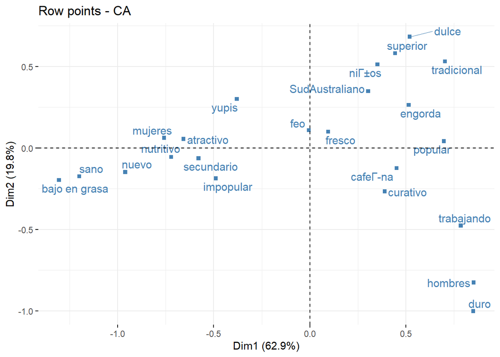

```r
# Los parámetros col.row y shape.row hacen referencial al color y forma de los puntos
fviz_ca_row(res.ca, col.row="steelblue", shape.row = 15, repel = TRUE)
```

#Calidad en la representación de los puntos fila

```r
row$cos2
```

```
##                    Dim 1     Dim 2      Dim 3      Dim 4      Dim 5
## engorda        0.6517775 0.1731405 2.3637e-02 0.14588314 0.00556179
## hombres        0.5119839 0.4798990 7.5082e-03 0.00013168 0.00047725
## SudAustraliano 0.1143411 0.1520207 6.9184e-01 0.03478534 0.00701266
## tradicional    0.4542740 0.2604166 2.6412e-03 0.27273761 0.00993056
## superior       0.2958957 0.5089968 1.2786e-01 0.06589755 0.00134521
## sano           0.9532153 0.0200859 5.8796e-05 0.01599006 0.01064995
## cafeГna       0.7022834 0.0529463 3.6123e-02 0.19788577 0.01076099
## nuevo          0.8933510 0.0209309 8.2718e-03 0.01037014 0.06707624
## atractivo      0.9113287 0.0065245 7.3845e-02 0.00630053 0.00200171
## duro           0.4036257 0.5601980 1.1447e-02 0.02018117 0.00454818
## popular        0.7708872 0.0028200 4.5467e-03 0.21676403 0.00498210
## curativo       0.4462490 0.2087577 8.7437e-03 0.19943852 0.13681107
## bajo en grasa  0.9407284 0.0212704 3.2984e-06 0.02085263 0.01714530
## niГ±os         0.1787390 0.3801669 3.1447e-01 0.11803790 0.00858828
## trabajando     0.6926314 0.2552844 1.5878e-02 0.03551442 0.00069131
## dulce          0.2119493 0.3678313 3.5896e-01 0.05168260 0.00957923
## impopular      0.5852331 0.0850023 1.7005e-02 0.31264402 0.00011575
## feo            0.0003443 0.1305981 3.9598e-01 0.47037862 0.00269489
## fresco         0.1963102 0.2135683 2.3937e-01 0.33344384 0.01730717
## yupis          0.3917847 0.2456886 2.4583e-01 0.03445209 0.08224048
## nutritivo      0.9457628 0.0055519 1.9332e-02 0.02919248 0.00016118
## mujeres        0.9649183 0.0066453 5.6997e-03 0.00812542 0.01461129
## secundario     0.5930219 0.0070789 1.8034e-02 0.21220214 0.16966317
```

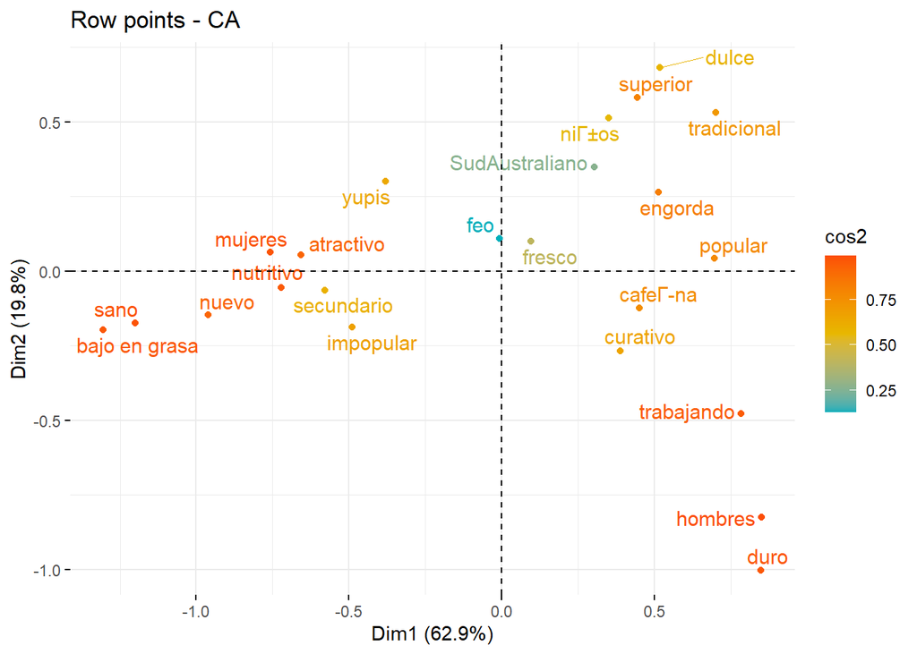

```r
fviz_ca_row(res.ca, col.row = "cos2",
             gradient.cols = c("#00AFBB", "#E7B800", "#FC4E07"),
             repel = TRUE)
```

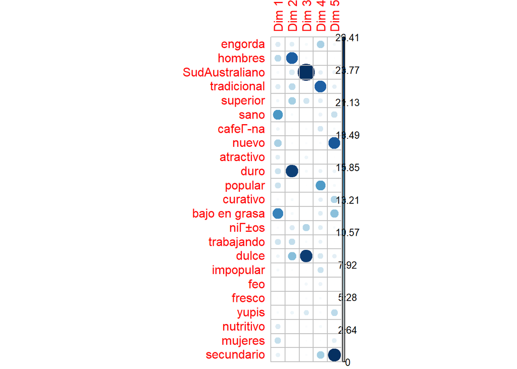

```r
library("corrplot")
corrplot(row$contrib, is.corr=FALSE)
```

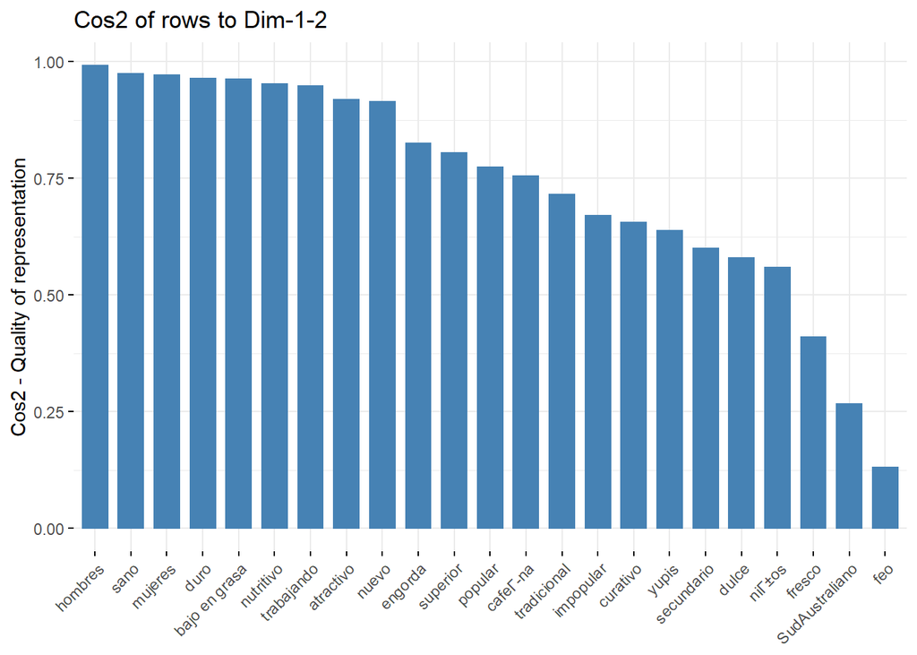

```r
library("FactoMineR")
library("factoextra")
fviz_cos2(res.ca, choice = "row", axes = 1:2)
```

#Contribuciones de las filas a las dimensiones

```r
row$contrib
```

```
##                     Dim 1     Dim 2      Dim 3     Dim 4      Dim 5
## engorda        4.1948e+00  3.544917 1.1094e+00  8.648723  1.2359392
## hombres        7.3337e+00 21.867856 7.8428e-01  0.017374  0.2360366
## SudAustraliano 1.0452e+00  4.420669 4.6118e+01  2.929013  2.2133161
## tradicional    3.8935e+00  7.100398 1.6508e-01 21.532709  2.9387498
## superior       1.6391e+00  8.969833 5.1653e+00  3.362623  0.2572963
## sano           1.5205e+01  1.019256 6.8394e-03  2.349531  5.8656220
## cafeГna       1.8784e+00  0.450519 7.0460e-01  4.875642  0.9938136
## nuevo          8.5627e+00  0.638216 5.7817e-01  0.915595 22.1984774
## atractivo      3.4780e+00  0.079211 2.0551e+00  0.221492  0.2637647
## duro           5.5780e+00 24.628088 1.1536e+00  2.569065  2.1702079
## popular        5.7519e+00  0.066936 2.4739e-01 14.898492  1.2835218
## curativo       7.6557e-01  1.139310 1.0939e-01  3.151724  8.1039305
## bajo en grasa  1.7485e+01  1.257668 4.4707e-04  3.570188 11.0029896
## niГ±os         5.9868e-01  4.050823 7.6811e+00  3.641918  0.9932306
## trabajando     5.4625e+00  6.404754 9.1320e-01  2.580016  0.1882467
## dulce          2.0201e+00 11.152669 2.4949e+01  4.537474  3.1523587
## impopular      1.1363e+00  0.525025 2.4077e-01  5.591641  0.0077596
## feo            1.8699e-04  0.225638 1.5683e+00  2.353224  0.0505349
## fresco         6.5120e-02  0.225374 5.7905e-01  1.018893  0.1982292
## yupis          9.6219e-01  1.919509 4.4028e+00  0.779400  6.9737384
## nutritivo      4.0853e+00  0.076291 6.0895e-01  1.161568  0.0240398
## mujeres        6.1847e+00  0.135499 2.6641e-01  0.479742  3.2336013
## secundario     2.6740e+00  0.101543 5.9299e-01  8.813953 26.4145952
```

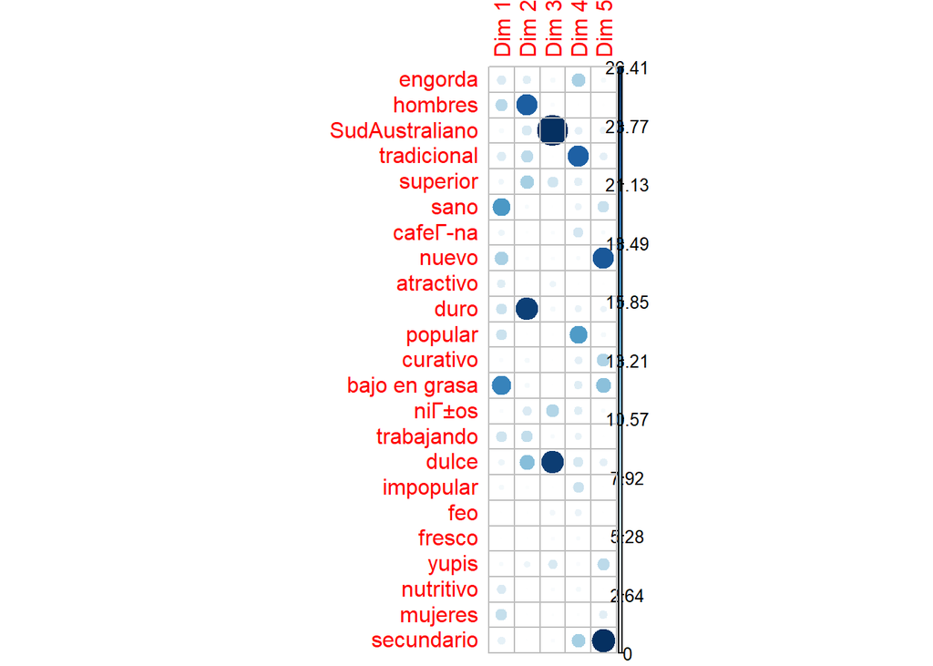

```r
library("corrplot")
corrplot(row$contrib, is.corr=FALSE)
```

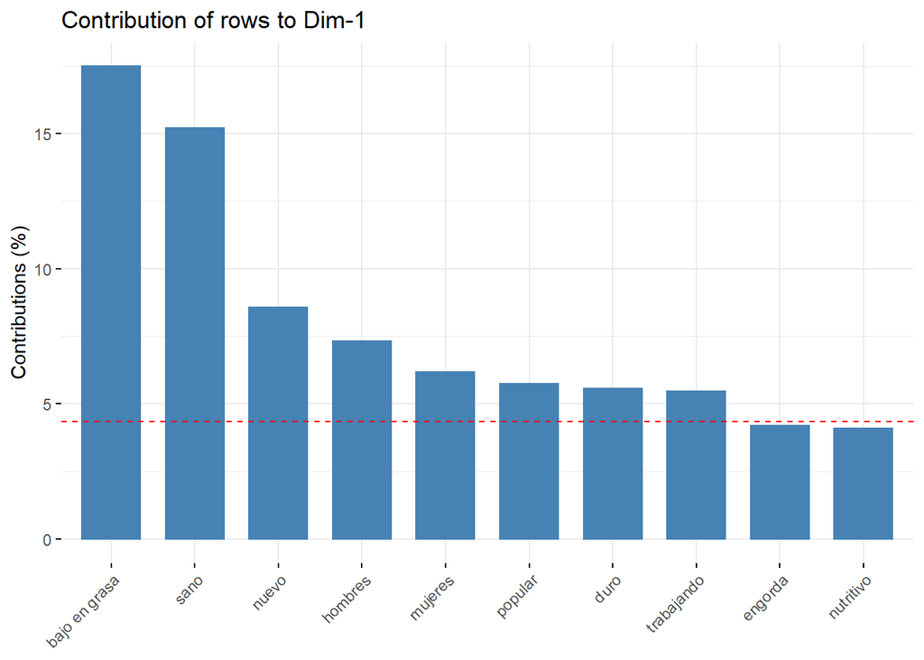

```r
# Contribuciones de filas a la dimensión 1
fviz_contrib(res.ca, choice = "row", axes = 1, top = 10)
```

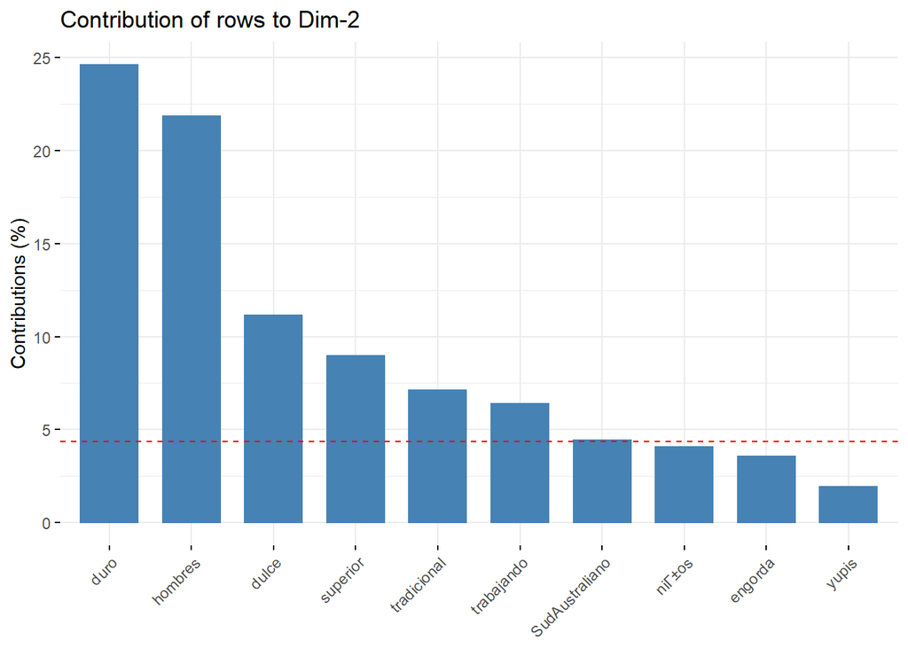

```r
# Contribuciones de filas a la dimensión 2
fviz_contrib(res.ca, choice = "row", axes = 2, top = 10)
```

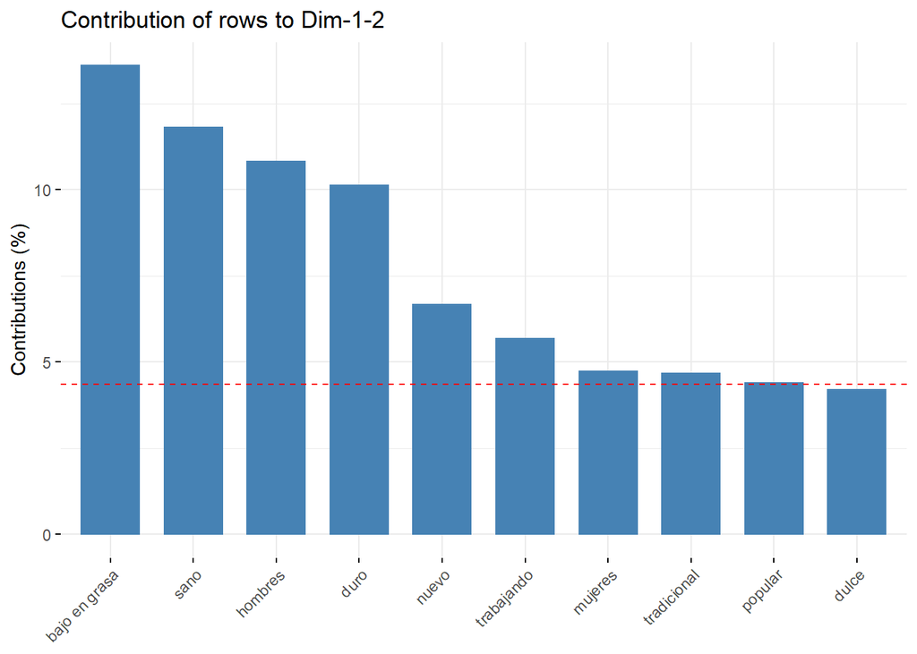

```r
# Total contribución a las dimensiones 1 y 2
fviz_contrib(res.ca, choice = "row", axes = 1:2, top = 10)
```

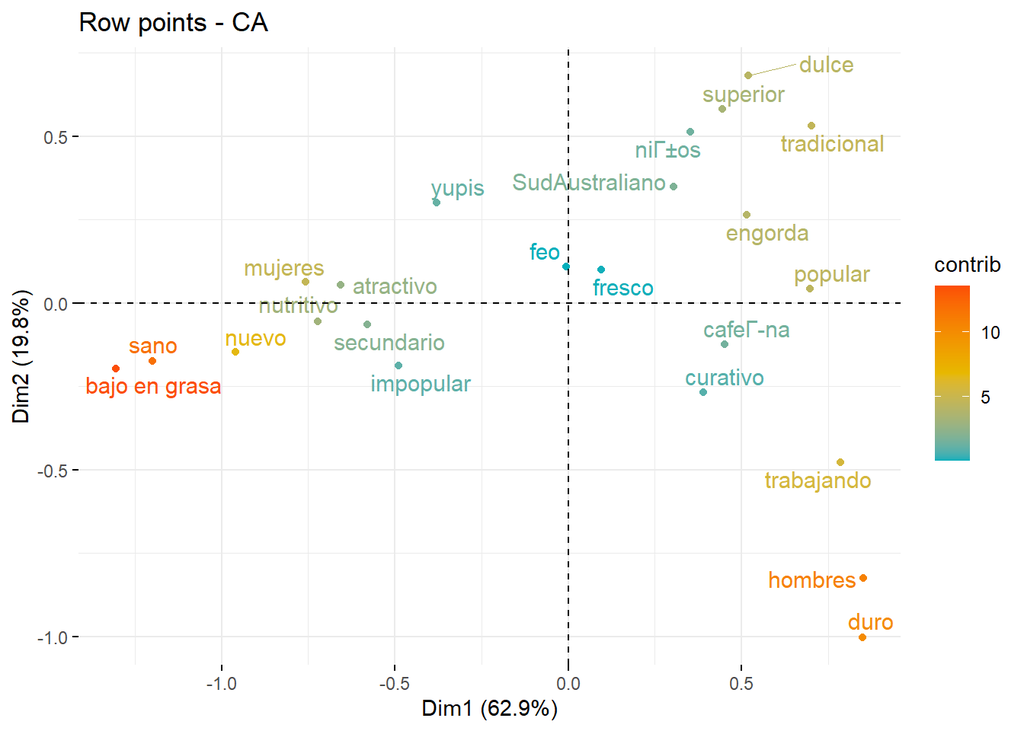

```r
# Cambio en los colores según los valores de contribución
fviz_ca_row(res.ca, col.row = "contrib",
             gradient.cols = c("#00AFBB", "#E7B800", "#FC4E07"),
             repel = TRUE)
```

# Análisis de perfiles columna

```r
col <- get_ca_col(res.ca)
col
```

```
## Correspondence Analysis - Results for columns
##  ===================================================
##   Name       Description
## 1 "$coord"   "Coordinates for the columns"
## 2 "$cos2"    "Cos2 for the columns"
## 3 "$contrib" "contributions of the columns"
## 4 "$inertia" "Inertia of the columns"
```

```r
# Coordenadas de puntos columna
col$coord
```

```
##            Dim 1     Dim 2     Dim 3     Dim 4     Dim 5
## frec.AA  0.65927 -0.045984  0.100875 -0.367916  0.042319
## frec.BB  0.28416  0.403515  0.517867  0.293144 -0.014771
## frec.CC -0.99555 -0.076093  0.023504 -0.112941 -0.178385
## frec.DD -0.91502 -0.100756 -0.044928  0.061694  0.222311
## frec.EE  0.65051 -0.706190 -0.133687  0.258839 -0.042710
## frec.FF  0.34288  0.618376 -0.433772  0.084759 -0.023991
```

```r
# Calidad de representación (contribución relativa)
col$cos2
```

```
##           Dim 1     Dim 2      Dim 3     Dim 4      Dim 5
## frec.AA 0.74414 0.0036203 0.01742163 0.2317516 0.00306621
## frec.BB 0.13505 0.2723233 0.44853994 0.1437233 0.00036491
## frec.CC 0.95113 0.0055566 0.00053015 0.0122410 0.03053739
## frec.DD 0.92755 0.0112466 0.00223623 0.0042167 0.05475181
## frec.EE 0.41957 0.4944733 0.01772069 0.0664292 0.00180863
## frec.FF 0.16895 0.5495102 0.27039208 0.0103238 0.00082709
```

```r
# Contribuciones
col$contrib
```

```
##           Dim 1    Dim 2    Dim 3   Dim 4    Dim 5
## frec.AA 18.6532  0.28869  3.18462 53.5122  2.65379
## frec.BB  2.0922 13.42135 50.67466 20.5106  0.19520
## frec.CC 36.2307  0.67334  0.14727  4.2952 40.16362
## frec.DD 26.7361  1.03127  0.47005  1.1196 54.49115
## frec.EE 12.7231 47.70066  3.91869 18.5558  1.89368
## frec.FF  3.5647 36.88468 41.60471  2.0065  0.60255
```

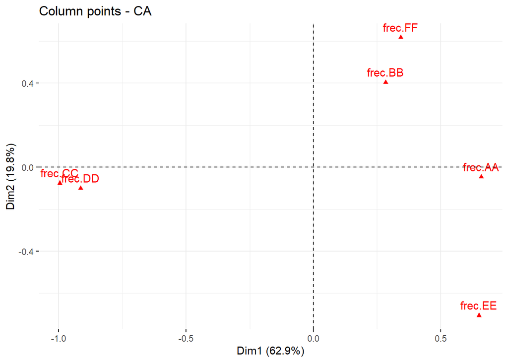

```r
# Gráfico simple
fviz_ca_col(res.ca)
```

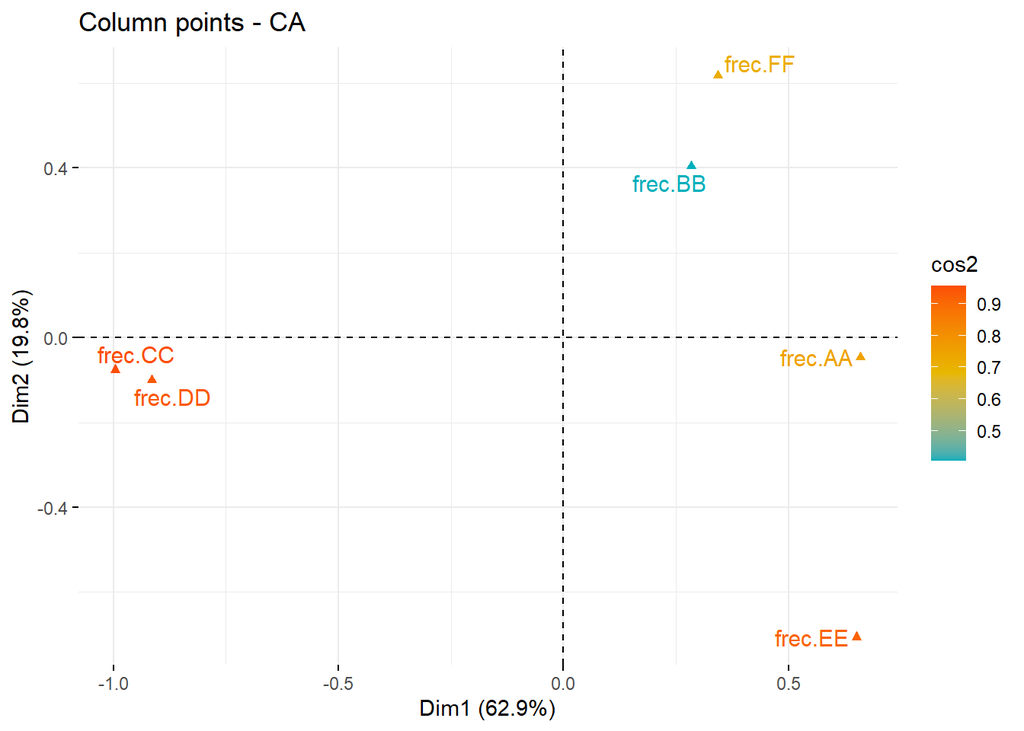

```r
# Cambio de color según valores de cos2
fviz_ca_col(res.ca, col.col = "cos2",
             gradient.cols = c("#00AFBB", "#E7B800", "#FC4E07"),
             repel = TRUE)
```

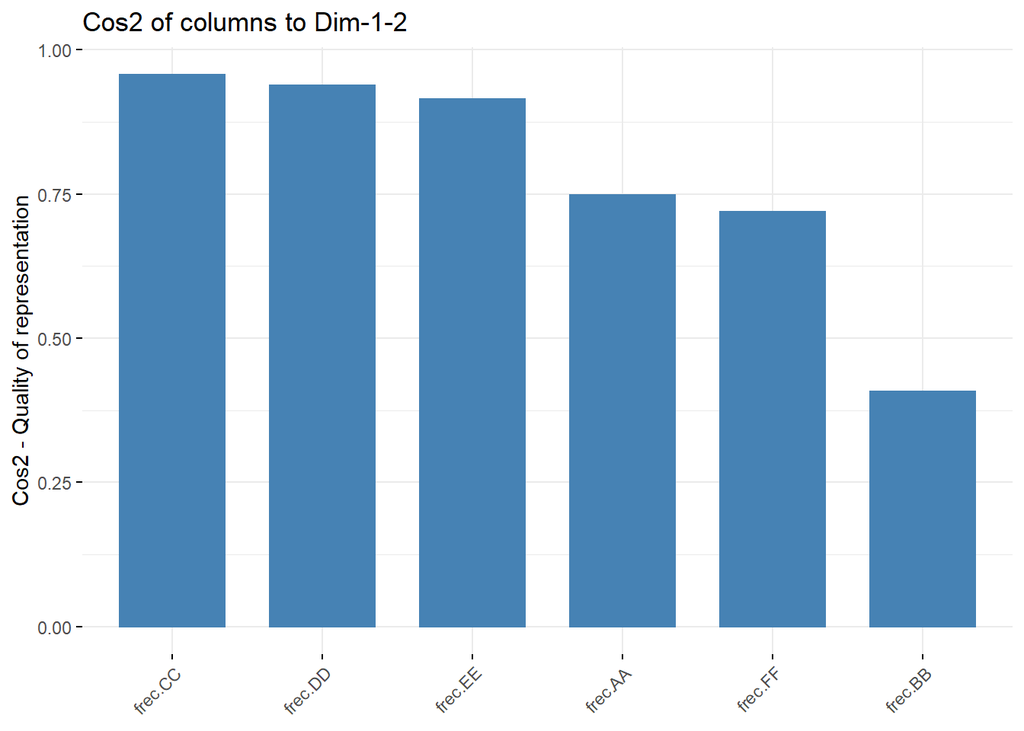

```r
# Gráfico de barras de cos2
fviz_cos2(res.ca, choice = "col", axes = 1:2)
```

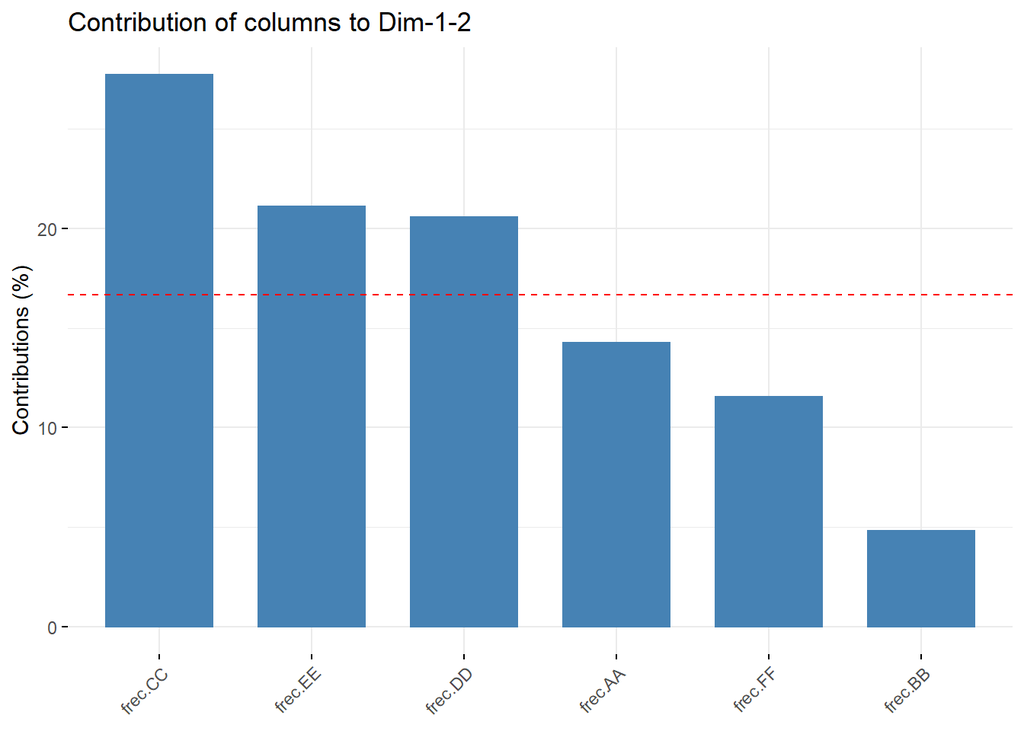

```r
# Gráfico de barras de contribuciones
fviz_contrib(res.ca, choice = "col", axes = 1:2)
```

# Biplots asimétricos

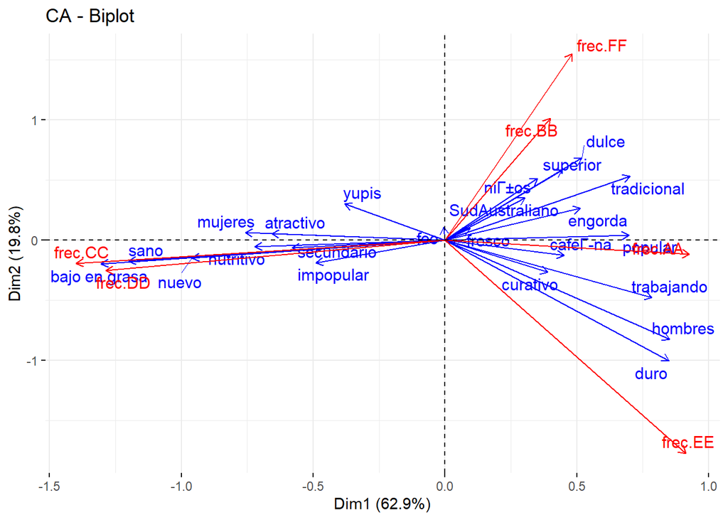

```r
fviz_ca_biplot(res.ca,
               map ="rowprincipal", arrow = c(TRUE, TRUE),
               repel = TRUE)
```

# Biplot de contribución

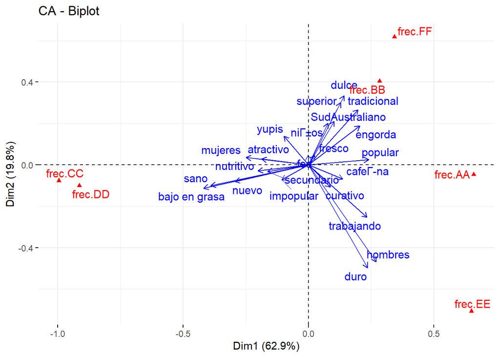

```r
fviz_ca_biplot(res.ca, map ="colgreen", arrow = c(TRUE, FALSE),
               repel = TRUE)
```

# Ejercicio 4

#La base de datos Cars93 incluida en la librería “MASS” contiene una selección aleatoria de 93 modelos de automóviles de pasajeros de 1993 que se enumeraron tanto en la edición de Consumer Reports como en la Guía de compras de PACE. Las camionetas y los vehículos deportivos / utilitarios fueron eliminados debido a la información incompleta en la fuente de Consumer Reports. Los modelos duplicados (por ejemplo, Dodge Shadow y Plymouth Sundance) se enumeraron como máximo una vez.

#Plantee un análisis de correlación canónica entre las variables asociadas a las características físicas de los vehículos (tamaño de motor, caballos de fuerza, longitud, distancia entre ejes, anchura, asiento trasero y peso) y las relativas al precio y el funcionamiento (precio medio, consumo en ciudad, consumo en carretera y espacio de giro en U).

```r
library(MASS)
data("Cars93")
str(Cars93)
```

```
## 'data.frame':    93 obs. of  27 variables:
##  $ Manufacturer      : Factor w/ 32 levels "Acura","Audi",..: 1 1 2 2 3 4 4 4 4 5 ...
##  $ Model             : Factor w/ 93 levels "100","190E","240",..: 49 56 9 1 6 24 54 74 73 35 ...
##  $ Type              : Factor w/ 6 levels "Compact","Large",..: 4 3 1 3 3 3 2 2 3 2 ...
##  $ Min.Price         : num  12.9 29.2 25.9 30.8 23.7 14.2 19.9 22.6 26.3 33 ...
##  $ Price             : num  15.9 33.9 29.1 37.7 30 15.7 20.8 23.7 26.3 34.7 ...
##  $ Max.Price         : num  18.8 38.7 32.3 44.6 36.2 17.3 21.7 24.9 26.3 36.3 ...
##  $ MPG.city          : int  25 18 20 19 22 22 19 16 19 16 ...
##  $ MPG.highway       : int  31 25 26 26 30 31 28 25 27 25 ...
##  $ AirBags           : Factor w/ 3 levels "Driver & Passenger",..: 3 1 2 1 2 2 2 2 2 2 ...
##  $ DriveTrain        : Factor w/ 3 levels "4WD","Front",..: 2 2 2 2 3 2 2 3 2 2 ...
##  $ Cylinders         : Factor w/ 6 levels "3","4","5","6",..: 2 4 4 4 2 2 4 4 4 5 ...
##  $ EngineSize        : num  1.8 3.2 2.8 2.8 3.5 2.2 3.8 5.7 3.8 4.9 ...
##  $ Horsepower        : int  140 200 172 172 208 110 170 180 170 200 ...
##  $ RPM               : int  6300 5500 5500 5500 5700 5200 4800 4000 4800 4100 ...
##  $ Rev.per.mile      : int  2890 2335 2280 2535 2545 2565 1570 1320 1690 1510 ...
##  $ Man.trans.avail   : Factor w/ 2 levels "No","Yes": 2 2 2 2 2 1 1 1 1 1 ...
##  $ Fuel.tank.capacity: num  13.2 18 16.9 21.1 21.1 16.4 18 23 18.8 18 ...
##  $ Passengers        : int  5 5 5 6 4 6 6 6 5 6 ...
##  $ Length            : int  177 195 180 193 186 189 200 216 198 206 ...
##  $ Wheelbase         : int  102 115 102 106 109 105 111 116 108 114 ...
##  $ Width             : int  68 71 67 70 69 69 74 78 73 73 ...
##  $ Turn.circle       : int  37 38 37 37 39 41 42 45 41 43 ...
##  $ Rear.seat.room    : num  26.5 30 28 31 27 28 30.5 30.5 26.5 35 ...
##  $ Luggage.room      : int  11 15 14 17 13 16 17 21 14 18 ...
##  $ Weight            : int  2705 3560 3375 3405 3640 2880 3470 4105 3495 3620 ...
##  $ Origin            : Factor w/ 2 levels "USA","non-USA": 2 2 2 2 2 1 1 1 1 1 ...
##  $ Make              : Factor w/ 93 levels "Acura Integra",..: 1 2 4 3 5 6 7 9 8 10 ...
```

```r
summary(Cars93)
```

```
##     Manufacturer     Model         Type      Min.Price        Price
##  Chevrolet: 8    100    : 1   Compact:16   Min.   : 6.7   Min.   : 7.4
##  Ford     : 8    190E   : 1   Large  :11   1st Qu.:10.8   1st Qu.:12.2
##  Dodge    : 6    240    : 1   Midsize:22   Median :14.7   Median :17.7
##  Mazda    : 5    300E   : 1   Small  :21   Mean   :17.1   Mean   :19.5
##  Pontiac  : 5    323    : 1   Sporty :14   3rd Qu.:20.3   3rd Qu.:23.3
##  Buick    : 4    535i   : 1   Van    : 9   Max.   :45.4   Max.   :61.9
##  (Other)  :57    (Other):87
##    Max.Price       MPG.city     MPG.highway                 AirBags
##  Min.   : 7.9   Min.   :15.0   Min.   :20.0   Driver & Passenger:16
##  1st Qu.:14.7   1st Qu.:18.0   1st Qu.:26.0   Driver only       :43
##  Median :19.6   Median :21.0   Median :28.0   None              :34
##  Mean   :21.9   Mean   :22.4   Mean   :29.1
##  3rd Qu.:25.3   3rd Qu.:25.0   3rd Qu.:31.0
##  Max.   :80.0   Max.   :46.0   Max.   :50.0
##
##  DriveTrain  Cylinders    EngineSize     Horsepower       RPM
##  4WD  :10   3     : 3   Min.   :1.00   Min.   : 55   Min.   :3800
##  Front:67   4     :49   1st Qu.:1.80   1st Qu.:103   1st Qu.:4800
##  Rear :16   5     : 2   Median :2.40   Median :140   Median :5200
##             6     :31   Mean   :2.67   Mean   :144   Mean   :5281
##             8     : 7   3rd Qu.:3.30   3rd Qu.:170   3rd Qu.:5750
##             rotary: 1   Max.   :5.70   Max.   :300   Max.   :6500
##
##   Rev.per.mile  Man.trans.avail Fuel.tank.capacity   Passengers       Length
##  Min.   :1320   No :32          Min.   : 9.2       Min.   :2.00   Min.   :141
##  1st Qu.:1985   Yes:61          1st Qu.:14.5       1st Qu.:4.00   1st Qu.:174
##  Median :2340                   Median :16.4       Median :5.00   Median :183
##  Mean   :2332                   Mean   :16.7       Mean   :5.09   Mean   :183
##  3rd Qu.:2565                   3rd Qu.:18.8       3rd Qu.:6.00   3rd Qu.:192
##  Max.   :3755                   Max.   :27.0       Max.   :8.00   Max.   :219
##
##    Wheelbase       Width       Turn.circle Rear.seat.room  Luggage.room
##  Min.   : 90   Min.   :60.0   Min.   :32   Min.   :19.0   Min.   : 6.0
##  1st Qu.: 98   1st Qu.:67.0   1st Qu.:37   1st Qu.:26.0   1st Qu.:12.0
##  Median :103   Median :69.0   Median :39   Median :27.5   Median :14.0
##  Mean   :104   Mean   :69.4   Mean   :39   Mean   :27.8   Mean   :13.9
##  3rd Qu.:110   3rd Qu.:72.0   3rd Qu.:41   3rd Qu.:30.0   3rd Qu.:15.0
##  Max.   :119   Max.   :78.0   Max.   :45   Max.   :36.0   Max.   :22.0
##                                            NA's   :2      NA's   :11
##      Weight         Origin              Make
##  Min.   :1695   USA    :48   Acura Integra: 1
##  1st Qu.:2620   non-USA:45   Acura Legend : 1
##  Median :3040                Audi 100     : 1
##  Mean   :3073                Audi 90      : 1
##  3rd Qu.:3525                BMW 535i     : 1
##  Max.   :4105                Buick Century: 1
##                              (Other)      :87
```

```r
head(Cars93)
```

```
##   Manufacturer   Model    Type Min.Price Price Max.Price MPG.city MPG.highway
## 1        Acura Integra   Small      12.9  15.9      18.8       25          31
## 2        Acura  Legend Midsize      29.2  33.9      38.7       18          25
## 3         Audi      90 Compact      25.9  29.1      32.3       20          26
## 4         Audi     100 Midsize      30.8  37.7      44.6       19          26
## 5          BMW    535i Midsize      23.7  30.0      36.2       22          30
## 6        Buick Century Midsize      14.2  15.7      17.3       22          31
##              AirBags DriveTrain Cylinders EngineSize Horsepower  RPM
## 1               None      Front         4        1.8        140 6300
## 2 Driver & Passenger      Front         6        3.2        200 5500
## 3        Driver only      Front         6        2.8        172 5500
## 4 Driver & Passenger      Front         6        2.8        172 5500
## 5        Driver only       Rear         4        3.5        208 5700
## 6        Driver only      Front         4        2.2        110 5200
##   Rev.per.mile Man.trans.avail Fuel.tank.capacity Passengers Length Wheelbase
## 1         2890             Yes               13.2          5    177       102
## 2         2335             Yes               18.0          5    195       115
## 3         2280             Yes               16.9          5    180       102
## 4         2535             Yes               21.1          6    193       106
## 5         2545             Yes               21.1          4    186       109
## 6         2565              No               16.4          6    189       105
##   Width Turn.circle Rear.seat.room Luggage.room Weight  Origin          Make
## 1    68          37           26.5           11   2705 non-USA Acura Integra
## 2    71          38           30.0           15   3560 non-USA  Acura Legend
## 3    67          37           28.0           14   3375 non-USA       Audi 90
## 4    70          37           31.0           17   3405 non-USA      Audi 100
## 5    69          39           27.0           13   3640 non-USA      BMW 535i
## 6    69          41           28.0           16   2880     USA Buick Century
```